# Q5 – Do schizophrenia and bipolar disorder show an accelerated-ageing-like transcriptomic profile?

Ageing hallmark scores per cell type and donor, compared between patients and controls of the same age

Author

Ann-Solène Adelson

Published

November 20, 2026

**NoteHow to read this notebook**

Each step starts with a short explanation of **what we do and why**, then the code. Every figure comes with:

- a **legend** (“Figure Q5-Fxx”), written so that it can be copied into the report or the appendix;
- a **“How to read”** box, to understand the figure without knowing the method;
- an **“Interpretation”** box with the HBCC results.

The notebook makes **4 figures** and one diagram, each one answering a part of the question; checks and intermediate results are tables. Figures are saved as `.png` in `04_FIGURES/Q5_aging/`. References are numbered in square brackets and listed at the end.

# Overview

## Question and hypothesis

**Central question of the project.** Do schizophrenia (SCZ) and bipolar disorder (BD) share cell-type-specific molecular alterations in the human prefrontal cortex, and could these changes reflect accelerated ageing and affect neuronal and glial signalling networks?

**Question of this notebook (Q5).** *Do SCZ and BD show an accelerated-ageing-like transcriptomic profile in specific neuronal or glial populations?*

**Hypothesis tested (H3).** In some cell populations, patients may have the transcriptomic profile of older controls, in a way that is shared by the two disorders or specific to one of them.

## Why this question

Ageing is not a single process: it is described by a set of **hallmarks** [1], such as chronic inflammation, cellular senescence or mitochondrial dysfunction, plus changes specific to the brain, such as the loss of myelin [2]. Whether the brain ages faster in schizophrenia is **debated**: brain age estimated from MRI is older than chronological age in patients [3], whereas an epigenetic clock measured on post-mortem cortex found no acceleration [4]. A recent single-nucleus study of the orbitofrontal cortex found that genes changed with age and genes changed in psychiatric disease (mostly schizophrenia) overlap and change in the same direction, and that patients have an older transcriptomic age, but not an older epigenetic age [5]. In the dorsolateral prefrontal cortex, a gene program shared by neurons and astrocytes declines both with age and in schizophrenia [6]. We extend this question to the dorsolateral prefrontal cortex of the HBCC cohort, compare **SCZ and BD** directly, and ask **which ageing hallmarks** are involved in each cell type.

## What we look for, and what we do not claim

**What we look for.** We do not test whether patients *age* faster, which cannot be shown with one sample per donor. We ask whether, in some cell types, patients have the transcriptomic profile of **older controls**: for example, a 25-year-old patient whose microglia look like those of a 45-year-old control.

**How.** The notebook has two parts.

- **Part A – Published ageing signatures.** For each ageing hallmark, a **published gene signature** is scored per donor and cell type. The **controls** define what is normal at each age. The scores that follow age in controls are combined into one **composite ageing score** per cell type, and patients are compared with controls **of the same age**. The difference is also expressed as an **apparent age gap** (in years).
- **Part B – All genes.** Part A depends on gene lists chosen in advance. Part B uses **all genes** and checks whether the genes changed by the disease (Q2) change in the same direction as the genes changed by age.

**What we will not claim.** A profile that resembles ageing does not mean that the disease causes ageing: treatments, smoking, metabolic disorders and cause of death are other possible explanations, discussed as limits.

**Why signature scores.** Each hallmark is measured with `AddModuleScore()` [7], the Seurat function used in the practicals to score gene signatures. It gives one interpretable number for a named biological process, it corrects for the general expression level, and it only needs published gene lists, which suits a cohort with a limited number of controls per cell type.

**Why on pseudobulk profiles.** The question is about **donors** (“does this patient look like an older control?”), so the donor is the unit of analysis. The scores are computed on the **pseudobulk** matrix of the preprocessing: for each donor and cell type, the counts of **all** its nuclei are summed, which gives one expression profile per donor and cell type, like a bulk RNA-seq of that sorted population. This is the unit used for differential expression in the PsychAD atlas [8] and for the program that declines with age and in schizophrenia described by Ling et al. [6]. It uses every nucleus (the shared Seurat object keeps only 200 nuclei per donor, for visualisation), and it is the same input as the differential expression of Q2, so the two questions can be compared.

## The scores used

Each hallmark is measured by a published signature, and only in the cell types where it makes biological sense, which also limits the number of tests.

| Hallmark | Signature | Tested in | Ref. |
| --- | --- | --- | --- |
| Cellular senescence | SenMayo | microglia, astrocytes | [1, 9] |
| Chronic inflammation (“inflammaging”) | Hallmark Inflammatory Response; Hallmark TNFα signalling via NF-κB | microglia, astrocytes | [1, 2, 10] |
| Microglial ageing | genes rising / falling with age in human cortical microglia (GalatroAging) | microglia | [11] |
| Mitochondrial dysfunction | Hallmark Oxidative Phosphorylation | every cell type | [1, 2, 10] |
| Loss of myelin (brain-specific) | GO “ensheathment of neurons” (contains myelination) | oligodendrocytes, OPC | [2, 12] |
| Global transcriptomic age of the cell type | genes rising / falling with age in adult DLPFC (PsychAD lifespan atlas) | every cell type with a lifespan signature | [13] |

The cell types are **all the subclasses with enough donors** (shared rule, Step 1), the same as in Q2 and Q3, and not only the two subclasses whose proportion changes in Q1 (microglia and oligodendrocytes): a cell type can be altered in its expression without changing in number. Senescence and inflammation are tested in microglia and astrocytes, myelination in oligodendrocytes and OPC.

| Term | Meaning in this notebook |
| --- | --- |
| **Pseudobulk profile** | for one donor and one cell type, the sum of the counts of all its nuclei |
| **Score** | one number per donor and cell type: how strongly the signature genes are expressed in its pseudobulk profile |
| **Validated score** | a score that follows age in our controls, in that cell type |
| **Composite ageing score** | for each cell type, the mean of its validated scores, oriented so that higher = older-looking: the **main measure** of Part A |
| **Apparent age gap** | how many years older (or younger) patients look than controls of the same age; given with a 95 % confidence interval, or “not estimable” when the score does not clearly follow age |

## Plan

The notebook follows three stages, summarised below: each box is a step and a question, with the figure or table that answers it.

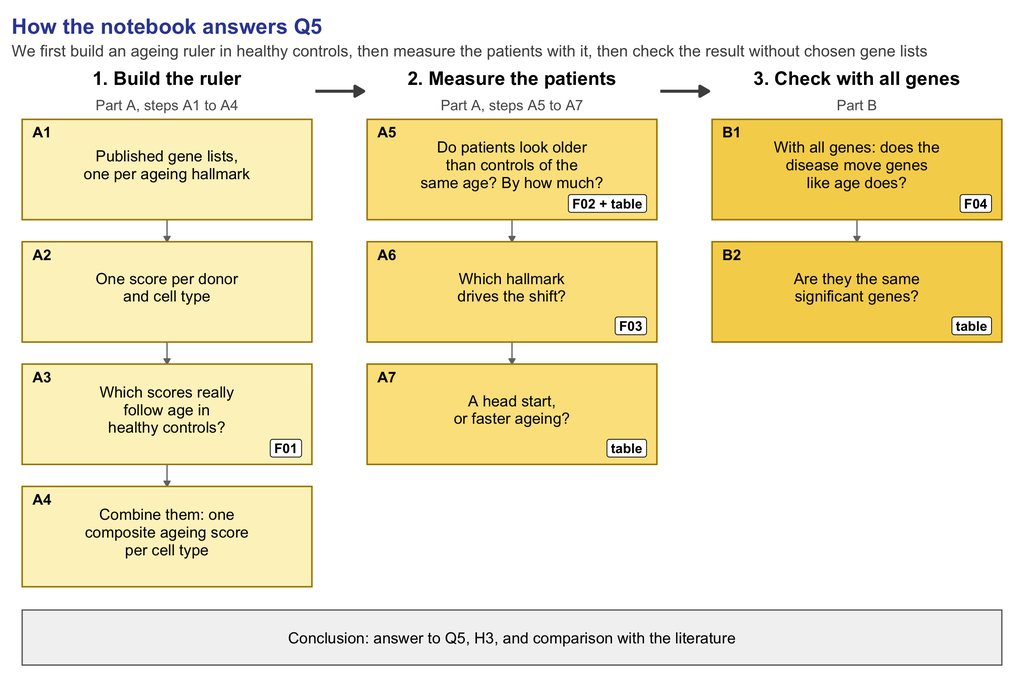

Figure 1

**How the notebook answers Q5.** We first build an ageing ruler in healthy controls (Part A, steps A1 to A4), then measure the patients with it (Part A, steps A5 to A7), then check the result without chosen gene lists (Part B). Step 1 (donors and cell types) comes before Part A; the conclusion gathers all the answers.

# Setup

| Package | Used for |
| --- | --- |
| `Seurat` | `NormalizeData()` and `AddModuleScore()` (seen in the practicals) |
| `dplyr`, `tidyr`, `ggplot2`, `patchwork` | tables and figures (`patchwork` assembles lettered panels) |

```r
the.seed <- 42          # AddModuleScore draws control genes at random: a fixed seed makes it reproducible
set.seed(the.seed)

suppressPackageStartupMessages({
  library(Seurat)
  library(dplyr)
  library(tidyr)
  library(ggplot2)
  library(patchwork)
})

# Reusable functions, kept outside the notebook so the code below stays readable
source("scripts/utils_genesets.R")
source("scripts/utils_aging_scores.R")
source("scripts/utils_figures.R")     # common figure style, colours and saving (shared with the other notebooks)
```

All the choices are gathered in one place, so the analysis can be re-run with other values.

[output not shown]

`AddModuleScore()` is used with its default of 100 control genes per signature gene: more control genes give a more stable background estimate.

```r
# Inputs
pseudobulk_path <- "../01_DATA/processed/pseudobulk_HBCC_224donors.rds"     # preprocessing (all nuclei)
de_path       <- "../01_DATA/processed/de_results_all.csv"   # Q2 results, for Part B
geneset_dir   <- "../01_DATA/genesets"   # one CSV per signature (gs_name, gene_symbol), see its README.md
signature_files <- c("Q5_senmayo.csv", "Q5_inflammatory_response.csv", "Q5_tnfa_nfkb.csv",
                     "Q5_microglia_ageing_galatro.csv", "Q5_oxphos.csv", "Q5_myelination.csv")
lifespan_path <- file.path(geneset_dir, "Q5_lifespan_ageing.csv")

# Outputs
out_dir <- "../03_RESULTS/Q5_aging"
fig_dir <- "../04_FIGURES/Q5_aging"
dir.create(out_dir, recursive = TRUE, showWarnings = FALSE)
dir.create(fig_dir, recursive = TRUE, showWarnings = FALSE)
save_figure(p_reasoning, "Q5_reasoning", fig_dir, width = 12, height = 8)   # diagram of the Overview

# Analysis choices
min_nuclei      <- 20
min_donors      <- 10
min_age         <- 20
min_genes       <- 5
covariates      <- c("sex", "ancestry")
n_perm          <- 1000
alpha           <- 0.05
cell_types      <- "all"                 # every subclass of the pseudobulk matrix, filtered by the shared rule (Step 1)

# In which cell types each signature is tested ("all" = every cell type).
# A name can be a subclass (Micro) or a class prefix (EN = every EN_* subclass).
signature_scope <- list(
  SenMayo               = c("Astro", "Micro"),
  Inflammatory_Response = c("Astro", "Micro"),
  TNFa_NFkB             = c("Astro", "Micro"),
  Microglia_AgingUp     = "Micro",
  Microglia_AgingDown   = "Micro",
  OxPhos                = "all",
  Myelination           = c("Oligo", "OPC"),
  Lifespan_AgingUp      = "all",
  Lifespan_AgingDown    = "all"
)

col_dx <- c(CTRL = "grey40", col_disease[c("SCZ", "BD")])
lab_dx <- c(SCZ = "SCZ vs controls", BD = "BD vs controls", SCZ_vs_BD = "SCZ vs BD (direct)")

# Diverging scale for ageing shifts: orange = older-looking, purple = younger-looking
scale_fill_shift <- function(lim, name) {
  scale_fill_gradient2(low = "#5e3c99", mid = "white", high = "#e66101", midpoint = 0,
                       limits = c(-lim, lim), name = name)
}
```

## Step 1 – Donors and cell types

**What we do and why.** We load the pseudobulk profiles made during preprocessing (one column per donor and subclass, raw counts of all nuclei summed). In a cross-sectional study, the main risk is **confounding**: if patients were younger or older than controls, age and diagnosis would be mixed up. We first check that the groups are comparable, then which cell types have enough donors.

```r
pb <- load_pseudobulk(pseudobulk_path)
pb_counts <- pb$counts   # genes x (donor x subclass), raw counts
pb_desc   <- pb$desc     # one row per column: donor_id, cell_type, n_nuclei, diagnosis, age, sex, ancestry

donor_meta <- pb_desc |>
  distinct(donor_id, diagnosis, age, sex, ancestry)

# Adult donors only (already done in preprocessing: this is a safety check)
n_young <- sum(donor_meta$age < min_age)
if (n_young > 0) {
  cat("Note:", n_young, "donors under", min_age, "years removed.\n")
  donor_meta <- filter(donor_meta, age >= min_age)
}

donor_meta |>
  group_by(diagnosis) |>
  summarise(n_donors     = n(),
            age_median   = median(age),
            age_range    = paste(min(age), "-", max(age)),
            n_age_60plus = sum(age >= 60),
            pct_female   = round(100 * mean(sex == "female")),
            pct_european = round(100 * mean(ancestry == "European", na.rm = TRUE)),
            pct_african  = round(100 * mean(ancestry == "African", na.rm = TRUE)),
            .groups = "drop")
```

| diagnosis | n_donors | age_median | age_range | n_age_60plus | pct_female | pct_european | pct_african |
| --- | --- | --- | --- | --- | --- | --- | --- |
| CTRL | 121 | 45 | 20 - 85 | 15 | 29 | 36 | 58 |
| SCZ | 49 | 53 | 21 - 75 | 13 | 43 | 24 | 65 |
| BD | 54 | 41 | 20 - 79 | 6 | 43 | 83 | 7 |

```r
kruskal.test(age ~ diagnosis, data = donor_meta)
```

```
    Kruskal-Wallis rank sum test

data:  age by diagnosis
Kruskal-Wallis chi-squared = 12.288, df = 2, p-value = 0.002146
```

**TipHow to read**

One row per group: number of donors, median and range of age at death, number of donors aged 60 or more, percentage of women, and percentage of donors of European and African genetic ancestry. The Kruskal–Wallis test checks whether the age distributions differ between groups (without assuming a normal distribution). The same information is in Table 1 of the report (preprocessing).

**ImportantInterpretation**

- The three groups cover a similar adult age range (controls 20–85, SCZ 21–75, BD 20–79 years), but their median ages differ (controls 45, SCZ 53, BD 41 years; Kruskal–Wallis p = 0.002): SCZ donors are older, BD donors younger. This is why every model compares patients with controls **of the same age**.
- Only 34 donors are 60 or older (15 controls, 13 SCZ, 6 BD): the effect of age is estimated mostly before 60, and the slope model has little power.
- Women are fewer among controls (29 %) than among patients (43 %), and ancestry is very unbalanced (83 % of BD donors of European ancestry, against 24 % of SCZ donors): sex and ancestry are covariates of every model.

**Which cell types are analysed.** All the subclasses of the pseudobulk matrix. A donor’s profile is used only if it was built from at least 20 nuclei, and a cell type is analysed only if at least 10 donors of **each** group have such a profile (shared rule).

```r
if (identical(cell_types, "all")) cell_types <- sort(unique(pb_desc$cell_type))
celltype_table <- select_celltypes(filter(pb_desc, donor_id %in% donor_meta$donor_id),
                                   cell_types, min_nuclei = min_nuclei, min_donors = min_donors)
celltype_table
```

| cell_type | CTRL | SCZ | BD | kept |
| --- | --- | --- | --- | --- |
| Adaptive | 10 | 1 | 3 | FALSE |
| Astro | 118 | 44 | 53 | TRUE |
| EN_L2_3_IT | 113 | 45 | 48 | TRUE |
| EN_L3_5_IT_1 | 95 | 39 | 40 | TRUE |
| EN_L3_5_IT_2 | 109 | 42 | 46 | TRUE |
| EN_L3_5_IT_3 | 106 | 39 | 45 | TRUE |
| EN_L5_6_NP | 83 | 27 | 35 | TRUE |
| EN_L6B | 74 | 25 | 33 | TRUE |
| EN_L6_CT | 86 | 31 | 35 | TRUE |
| EN_L6_IT_1 | 82 | 27 | 35 | TRUE |
| EN_L6_IT_2 | 55 | 19 | 26 | TRUE |
| Endo | 109 | 40 | 40 | TRUE |
| IN_ADARB2 | 96 | 37 | 38 | TRUE |
| IN_LAMP5_LHX6 | 90 | 29 | 40 | TRUE |
| IN_LAMP5_RELN | 103 | 38 | 46 | TRUE |
| IN_PVALB | 110 | 41 | 49 | TRUE |
| IN_PVALB_CHC | 96 | 34 | 42 | TRUE |
| IN_SST | 112 | 42 | 48 | TRUE |
| IN_VIP | 113 | 45 | 51 | TRUE |
| Micro | 112 | 38 | 46 | TRUE |
| OPC | 120 | 45 | 53 | TRUE |
| Oligo | 121 | 46 | 52 | TRUE |
| PC | 91 | 31 | 38 | TRUE |
| PVM | 22 | 3 | 6 | FALSE |
| SMC | 12 | 9 | 8 | FALSE |
| VLMC | 60 | 22 | 23 | TRUE |
| EN_L5_ET | 0 | 0 | 0 | FALSE |

```r
analysis_units <- celltype_table$cell_type[celltype_table$kept]
# Class of each cell type (EN_L6_IT_1 -> EN), used by signature_scope
unit_class <- setNames(sub("_.*", "", analysis_units), analysis_units)
```

**TipHow to read**

One row per subclass: number of donors of each group with a profile of at least 20 nuclei. `kept = FALSE`: not enough donors, the cell type is not analysed.

# Part A – Published ageing signatures

**The idea.** Ageing is described by a set of hallmarks (inflammation, senescence, mitochondrial dysfunction, loss of myelin…) [1, 2]. For several of them, published studies provide a **gene signature**: a list of genes that goes up or down with this process. If a cell type of a patient expresses an ageing signature like an older control does, its profile looks older.

**The steps.** We prepare the signatures (A1) and score each donor in each cell type (A2). We keep only the scores that really follow age in our controls (A3), and combine them into one **composite ageing score** per cell type (A4). We then compare patients with controls of the same age (A5), look for which hallmark drives the difference (A6), and test whether patients change faster with age (A7).

**What we expect.** Every comparison is made at equal age. If patients have an older-looking profile in a cell type, their score is higher than that of controls of the same age.

## Step A1 – The signatures

**What we do and why.** We load the published signatures listed in the overview. The lifespan signatures come from the PsychAD lifespan atlas [13], which studied the same brain region with the same technique: for each subclass, the genes that change with age **in adulthood** (age groups 20–39, 40–59 and ≥ 60 years; childhood excluded), split into genes that rise and genes that fall with age.

**Why some cell types have no lifespan signature.** Unlike the other signatures, which are the same gene list for every cell type, the lifespan signatures are **specific to each subclass**. For several subclasses, mostly neurons, the atlas reports few or no genes changing with age in adulthood. We kept only lists of **at least 10 genes**: a score computed on fewer genes is unstable, 10 is the usual minimum size of a gene set in enrichment tools (10 in clusterProfiler, 15 in GSEA), and a recent benchmark found that signature scores, including `AddModuleScore()`, are reliable with about 12–15 informative genes [14]. The 19 smaller lists were removed (see `01_DATA/genesets/README.md`). These subclasses are therefore tested only with the signatures that apply to every cell type.

```r
# One file per signature; myelination is the GO term "ensheathment of neurons" (GO:0007272), which contains
# myelination (GO:0042552)
common_sets <- bind_rows(lapply(file.path(geneset_dir, signature_files), read_geneset_file))
common_signatures <- term2gene_to_list(common_sets)
short_names <- c(SAUL_SEN_MAYO = "SenMayo", SENMAYO = "SenMayo",
                 HALLMARK_INFLAMMATORY_RESPONSE = "Inflammatory_Response",
                 HALLMARK_TNFA_SIGNALING_VIA_NFKB = "TNFa_NFkB",
                 HALLMARK_OXIDATIVE_PHOSPHORYLATION = "OxPhos",
                 GOBP_ENSHEATHMENT_OF_NEURONS = "Myelination",
                 GALATRO_AGING_UP = "Microglia_AgingUp", GALATRO_AGING_DOWN = "Microglia_AgingDown")
names(common_signatures) <- ifelse(names(common_signatures) %in% names(short_names),
                                   short_names[names(common_signatures)], names(common_signatures))

# Lifespan atlas genes: gs_name AGING_UP_<cell type> / AGING_DOWN_<cell type>
lifespan_sets <- read_geneset_file(lifespan_path)
if (is.null(lifespan_sets)) cat("Note: lifespan file not found, the lifespan signatures are skipped.\n")

# Signatures used for one analysis unit, following signature_scope
signatures_for_unit <- function(unit) {
  cl <- unit_class[[unit]]
  in_scope <- function(sig) any(signature_scope[[sig]] %in% c("all", unit, cl))
  sigs <- common_signatures[vapply(names(common_signatures), in_scope, logical(1))]
  if (!is.null(lifespan_sets)) {
    for (dir in c("UP", "DOWN")) {
      # the lifespan atlas may be annotated at subclass or class level: try the unit first, then its class
      for (key in c(unit, cl)) {
        genes <- lifespan_sets$gene_symbol[lifespan_sets$gs_name == paste0("AGING_", dir, "_", key)]
        if (length(genes) > 0) {
          sigs[[paste0("Lifespan_Aging", ifelse(dir == "UP", "Up", "Down"))]] <- genes
          break
        }
      }
    }
  }
  sigs
}

# Coverage: how many genes of each signature are in our data?
geneset_coverage(common_signatures, rownames(pb_counts))
```

| gs_name | n_genes | n_present | fraction_present |
| --- | --- | --- | --- |
| Microglia_AgingDown | 360 | 322 | 0.89 |
| Microglia_AgingUp | 212 | 177 | 0.83 |
| Myelination | 140 | 134 | 0.96 |
| Inflammatory_Response | 200 | 193 | 0.96 |
| OxPhos | 200 | 183 | 0.92 |
| TNFa_NFkB | 200 | 195 | 0.98 |
| SenMayo | 124 | 110 | 0.89 |

**TipHow to read**

`n_genes` = size of the signature; `n_present` = genes found in our data; `fraction_present` = their ratio. Missing genes are usually not expressed in the cortex.

**ImportantInterpretation**

- Every signature is well covered (83 % to 98 % of its genes are in our data; lowest: Microglia_AgingUp, 83 %). No signature needs to be dropped.

**Do the signatures overlap?** If two signatures share most of their genes, they are not independent evidence.

```r
sig_names <- names(common_signatures)
expand.grid(sig_a = sig_names, sig_b = sig_names, stringsAsFactors = FALSE) |>
  filter(sig_a < sig_b) |>
  mutate(shared_genes = mapply(function(a, b) length(intersect(common_signatures[[a]], common_signatures[[b]])), sig_a, sig_b),
         jaccard = mapply(function(a, b) {
           ga <- common_signatures[[a]]; gb <- common_signatures[[b]]
           round(length(intersect(ga, gb)) / length(union(ga, gb)), 2)
         }, sig_a, sig_b)) |>
  arrange(desc(jaccard))
```

| sig_a | sig_b | shared_genes | jaccard |
| --- | --- | --- | --- |
| Inflammatory_Response | TNFa_NFkB | 51 | 0.15 |
| SenMayo | TNFa_NFkB | 27 | 0.09 |
| Inflammatory_Response | SenMayo | 25 | 0.08 |
| Myelination | SenMayo | 6 | 0.02 |
| Inflammatory_Response | Microglia_AgingDown | 3 | 0.01 |
| Inflammatory_Response | Microglia_AgingUp | 4 | 0.01 |
| Microglia_AgingDown | Myelination | 5 | 0.01 |
| Microglia_AgingUp | Myelination | 2 | 0.01 |
| Inflammatory_Response | Myelination | 2 | 0.01 |
| Myelination | OxPhos | 2 | 0.01 |
| Myelination | TNFa_NFkB | 4 | 0.01 |
| Microglia_AgingDown | SenMayo | 3 | 0.01 |
| Microglia_AgingUp | SenMayo | 2 | 0.01 |
| Microglia_AgingDown | Microglia_AgingUp | 0 | 0.00 |
| Microglia_AgingDown | OxPhos | 2 | 0.00 |
| Microglia_AgingUp | OxPhos | 0 | 0.00 |
| Inflammatory_Response | OxPhos | 0 | 0.00 |
| Microglia_AgingDown | TNFa_NFkB | 2 | 0.00 |
| Microglia_AgingUp | TNFa_NFkB | 2 | 0.00 |
| OxPhos | TNFa_NFkB | 0 | 0.00 |
| OxPhos | SenMayo | 0 | 0.00 |

**TipHow to read**

One row per pair of signatures: number of shared genes and Jaccard index (shared genes / all genes of the two signatures; 0 = nothing in common, 1 = identical).

**ImportantInterpretation**

- The largest overlap is between the two inflammation signatures (51 genes, Jaccard index 0.15); SenMayo shares 25–27 genes with each of them (Jaccard ≤ 0.09). The other signatures share almost nothing (≤ 0.02).
- Senescence and inflammation are therefore not fully independent: a result found with all three counts as one piece of evidence, not three.

## Step A2 – Scores per donor and cell type

**How a score is computed.** For one cell type, the pseudobulk profiles of all donors are log-normalised (`NormalizeData()`, as in the practicals). `AddModuleScore()` then takes, for each donor, the mean expression of the signature genes and subtracts the mean expression of random “control” genes with a similar expression level. A positive score means that the signature genes are higher than comparable genes in that donor’s cells; using control genes of the same level removes the effect of sequencing depth.

**Why one profile per donor.** Nuclei of the same donor are not independent: they share the donor’s genetics, age, treatment and post-mortem conditions. Scoring nuclei and testing them as if they were independent would give many false positives (pseudoreplication, the same reason Q2 uses pseudobulk). The **donor** is the statistical unit: each donor has one profile per cell type (built from at least 20 nuclei), hence one score. Scores are then expressed as **z-scores relative to the controls** (1 unit = 1 standard deviation of the controls), so all scores are on the same scale. Summing nuclei gives slightly more weight to nuclei with many counts than averaging per-nucleus scores would; this is the standard pseudobulk approach. The effect of age on every gene in controls, used in Part B, is computed in the same loop.

```r
donor_scores_list <- list()
age_fits          <- list()   # effect of age on all genes in controls, per cell type (Part B)

for (u in analysis_units) {
  cols <- pb_desc$cell_type == u & pb_desc$n_nuclei >= min_nuclei & pb_desc$donor_id %in% donor_meta$donor_id
  counts_u <- pb_counts[, cols, drop = FALSE]
  donors_u <- pb_desc$donor_id[cols]

  scores_u <- score_pseudobulk_celltype(counts_u, donors_u, signatures_for_unit(u),
                                        seed = the.seed, min_genes = min_genes)
  if (!is.null(scores_u)) {
    donor_scores_list[[u]] <- scores_u |>
      mutate(cell_type = u, n_nuclei = pb_desc$n_nuclei[cols][match(donor_id, donors_u)], .before = 1)
  }
  age_fits[[u]] <- age_effects_in_controls(counts_u, donors_u, donor_meta, covariates = covariates,
                                           min_donors = min_donors)
}

donor_scores <- bind_rows(donor_scores_list) |>
  left_join(donor_meta, by = "donor_id") |>
  standardize_by_controls()

# Signatures scored in each cell type, and number of donors
donor_scores |>
  group_by(cell_type) |>
  summarise(n_donors   = n_distinct(donor_id),
            signatures = paste(sort(unique(signature)), collapse = ", "), .groups = "drop")
```

| cell_type | n_donors | signatures |
| --- | --- | --- |
| Astro | 215 | Inflammatory_Response, Lifespan_AgingUp, OxPhos, SenMayo, TNFa_NFkB |
| EN_L2_3_IT | 206 | Lifespan_AgingDown, Lifespan_AgingUp, OxPhos |
| EN_L3_5_IT_1 | 174 | OxPhos |
| EN_L3_5_IT_2 | 197 | Lifespan_AgingDown, Lifespan_AgingUp, OxPhos |
| EN_L3_5_IT_3 | 190 | Lifespan_AgingUp, OxPhos |
| EN_L5_6_NP | 145 | OxPhos |
| EN_L6B | 132 | OxPhos |
| EN_L6_CT | 152 | OxPhos |
| EN_L6_IT_1 | 144 | OxPhos |
| EN_L6_IT_2 | 100 | OxPhos |
| Endo | 189 | Lifespan_AgingDown, Lifespan_AgingUp, OxPhos |
| IN_ADARB2 | 171 | Lifespan_AgingDown, Lifespan_AgingUp, OxPhos |
| IN_LAMP5_LHX6 | 159 | OxPhos |
| IN_LAMP5_RELN | 187 | Lifespan_AgingDown, OxPhos |
| IN_PVALB | 200 | OxPhos |
| IN_PVALB_CHC | 172 | OxPhos |
| IN_SST | 202 | Lifespan_AgingUp, OxPhos |
| IN_VIP | 209 | Lifespan_AgingUp, OxPhos |
| Micro | 196 | Inflammatory_Response, Lifespan_AgingDown, Lifespan_AgingUp, Microglia_AgingDown, Microglia_AgingUp, OxPhos, SenMayo, TNFa_NFkB |
| OPC | 218 | Lifespan_AgingDown, Lifespan_AgingUp, Myelination, OxPhos |
| Oligo | 219 | Lifespan_AgingDown, Lifespan_AgingUp, Myelination, OxPhos |
| PC | 160 | OxPhos |
| VLMC | 105 | OxPhos |

**TipHow to read**

For each cell type, the number of donors scored and the signatures scored, following `signature_scope`. A signature can be missing if fewer than 5 of its genes are in the data, and the lifespan signatures exist only for the subclasses with a list of at least 10 genes (Step A1).

## Step A3 – Which scores really follow age?

**What we do and why.** A score is only an ageing measure if it changes with age in **healthy** donors. For each cell type and signature, we compute the Spearman correlation between the score and age in controls (rank-based, so robust to extreme values). A score is **validated** if this correlation is significant after correction; its **direction** is kept (+1 if it rises with age, −1 if it falls), so that every score can be read as “older-looking” afterwards.

The lifespan atlas was built partly on HBCC controls, very probably ours [13]: its signatures are expected to follow age in our controls. This is not independent evidence, but it is not a problem for the question, which compares **patients** with controls.

```r
validation <- validate_in_controls(donor_scores, min_donors = min_donors)
write.csv(validation, file.path(out_dir, "validation_controls.csv"), row.names = FALSE)

valid_pairs <- validation |>
  filter(p_adj < alpha) |>
  transmute(cell_type, signature, age_direction = sign(rho))
validation |> mutate(rho = round(rho, 2), validated = p_adj < alpha)
```

| cell_type | signature | n_donors | rho | p_value | p_adj | validated |
| --- | --- | --- | --- | --- | --- | --- |
| Astro | Inflammatory_Response | 118 | 0.08 | 0.4063525 | 0.4707908 | FALSE |
| Astro | Lifespan_AgingUp | 118 | 0.42 | 0.0000029 | 0.0000166 | TRUE |
| Astro | OxPhos | 118 | -0.13 | 0.1697787 | 0.2758904 | FALSE |
| Astro | SenMayo | 118 | 0.33 | 0.0003025 | 0.0014301 | TRUE |
| Astro | TNFa_NFkB | 118 | 0.25 | 0.0074257 | 0.0203231 | TRUE |
| EN_L2_3_IT | Lifespan_AgingDown | 113 | -0.78 | 0.0000000 | 0.0000000 | TRUE |
| EN_L2_3_IT | Lifespan_AgingUp | 113 | 0.49 | 0.0000000 | 0.0000003 | TRUE |
| EN_L2_3_IT | OxPhos | 113 | 0.18 | 0.0547229 | 0.1094457 | FALSE |
| EN_L3_5_IT_1 | OxPhos | 95 | 0.03 | 0.7609125 | 0.7764294 | FALSE |
| EN_L3_5_IT_2 | Lifespan_AgingDown | 109 | -0.84 | 0.0000000 | 0.0000000 | TRUE |
| EN_L3_5_IT_2 | Lifespan_AgingUp | 109 | 0.60 | 0.0000000 | 0.0000000 | TRUE |
| EN_L3_5_IT_2 | OxPhos | 109 | 0.11 | 0.2496037 | 0.3605387 | FALSE |
| EN_L3_5_IT_3 | Lifespan_AgingUp | 106 | 0.30 | 0.0016234 | 0.0058447 | TRUE |
| EN_L3_5_IT_3 | OxPhos | 106 | 0.14 | 0.1625044 | 0.2725880 | FALSE |
| EN_L5_6_NP | OxPhos | 83 | 0.15 | 0.1775732 | 0.2798123 | FALSE |
| EN_L6B | OxPhos | 74 | 0.19 | 0.1004090 | 0.1800438 | FALSE |
| EN_L6_CT | OxPhos | 86 | 0.28 | 0.0093574 | 0.0243294 | TRUE |
| EN_L6_IT_1 | OxPhos | 82 | 0.20 | 0.0681860 | 0.1313212 | FALSE |
| EN_L6_IT_2 | OxPhos | 55 | 0.10 | 0.4586465 | 0.4968670 | FALSE |
| Endo | Lifespan_AgingDown | 109 | -0.08 | 0.4210311 | 0.4707908 | FALSE |
| Endo | Lifespan_AgingUp | 109 | 0.09 | 0.3573947 | 0.4424887 | FALSE |
| Endo | OxPhos | 109 | 0.00 | 0.9676405 | 0.9676405 | FALSE |
| IN_ADARB2 | Lifespan_AgingDown | 96 | 0.10 | 0.3220341 | 0.4173888 | FALSE |
| IN_ADARB2 | Lifespan_AgingUp | 96 | 0.32 | 0.0017473 | 0.0058447 | TRUE |
| IN_ADARB2 | OxPhos | 96 | -0.18 | 0.0833863 | 0.1548603 | FALSE |
| IN_LAMP5_LHX6 | OxPhos | 90 | -0.17 | 0.1162930 | 0.2015745 | FALSE |
| IN_LAMP5_RELN | Lifespan_AgingDown | 103 | -0.25 | 0.0116797 | 0.0264063 | TRUE |
| IN_LAMP5_RELN | OxPhos | 103 | -0.08 | 0.4131090 | 0.4707908 | FALSE |
| IN_PVALB | OxPhos | 110 | -0.10 | 0.3193325 | 0.4173888 | FALSE |
| IN_PVALB_CHC | OxPhos | 96 | -0.27 | 0.0072114 | 0.0203231 | TRUE |
| IN_SST | Lifespan_AgingUp | 112 | 0.31 | 0.0010062 | 0.0042870 | TRUE |
| IN_SST | OxPhos | 112 | -0.11 | 0.2478181 | 0.3605387 | FALSE |
| IN_VIP | Lifespan_AgingUp | 113 | 0.30 | 0.0010717 | 0.0042870 | TRUE |
| IN_VIP | OxPhos | 113 | -0.09 | 0.3290950 | 0.4173888 | FALSE |
| Micro | Inflammatory_Response | 112 | 0.23 | 0.0129954 | 0.0281568 | TRUE |
| Micro | Lifespan_AgingDown | 112 | -0.38 | 0.0000416 | 0.0002161 | TRUE |
| Micro | Lifespan_AgingUp | 112 | 0.51 | 0.0000000 | 0.0000001 | TRUE |
| Micro | Microglia_AgingDown | 112 | -0.12 | 0.2004924 | 0.3066354 | FALSE |
| Micro | Microglia_AgingUp | 112 | 0.64 | 0.0000000 | 0.0000000 | TRUE |
| Micro | OxPhos | 112 | -0.04 | 0.6442530 | 0.6836970 | FALSE |
| Micro | SenMayo | 112 | 0.24 | 0.0114011 | 0.0264063 | TRUE |
| Micro | TNFa_NFkB | 112 | 0.24 | 0.0108673 | 0.0264063 | TRUE |
| OPC | Lifespan_AgingDown | 120 | -0.55 | 0.0000000 | 0.0000000 | TRUE |
| OPC | Lifespan_AgingUp | 120 | 0.41 | 0.0000029 | 0.0000166 | TRUE |
| OPC | Myelination | 120 | 0.09 | 0.3287864 | 0.4173888 | FALSE |
| OPC | OxPhos | 120 | 0.08 | 0.3747503 | 0.4531864 | FALSE |
| Oligo | Lifespan_AgingDown | 121 | -0.26 | 0.0044439 | 0.0135932 | TRUE |
| Oligo | Lifespan_AgingUp | 121 | 0.28 | 0.0017984 | 0.0058447 | TRUE |
| Oligo | Myelination | 121 | -0.07 | 0.4255224 | 0.4707908 | FALSE |
| Oligo | OxPhos | 121 | -0.21 | 0.0234051 | 0.0486827 | TRUE |
| PC | OxPhos | 91 | -0.11 | 0.2897657 | 0.4072383 | FALSE |
| VLMC | OxPhos | 60 | 0.04 | 0.7614980 | 0.7764294 | FALSE |

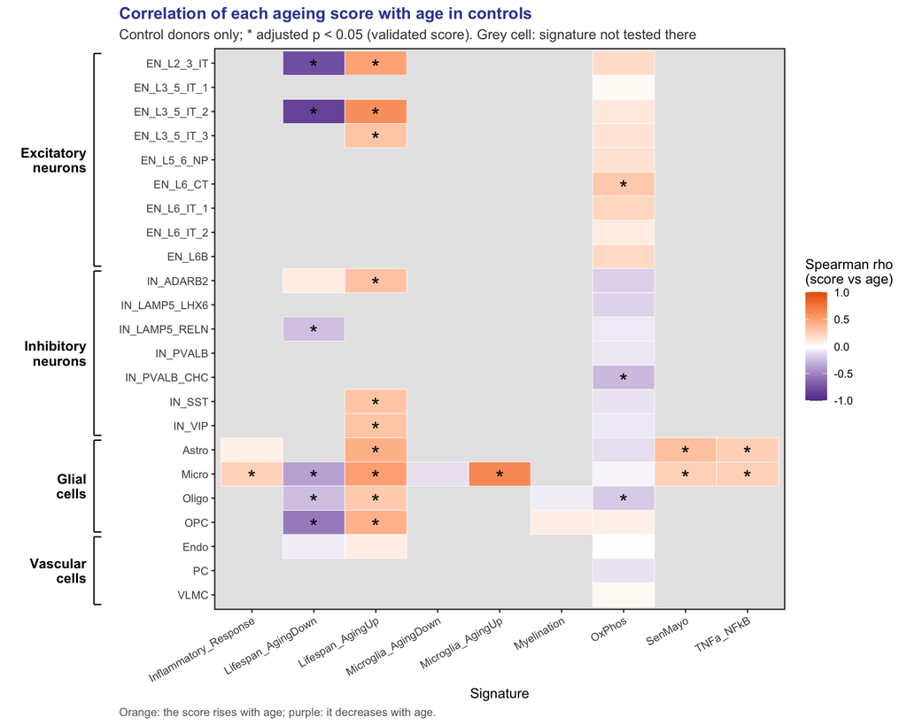

Figure 2

```r
# Cell types grouped by family (first family at the top); a bracket on the left names each family
lev <- rev(order_cell_types(validation$cell_type))
fam <- data.frame(y = seq_along(lev), family = cell_family(lev)) |>
  group_by(family) |>
  summarise(ymin = min(y) - 0.4, ymax = max(y) + 0.4, ymid = mean(y), .groups = "drop") |>
  mutate(label = sub(" ", "\n", family))
bx <- -1.55   # x position of the brackets, left of the cell-type names
p_F01 <- validation |>
  mutate(cell_type = factor(cell_type, levels = lev)) |>
  ggplot(aes(signature, cell_type, fill = rho)) +
  geom_tile(colour = "white") +
  geom_text(aes(label = ifelse(p_adj < alpha, "*", "")), size = 6, vjust = 0.75) +
  annotate("segment", x = bx, xend = bx, y = fam$ymin, yend = fam$ymax, linewidth = 0.5) +
  annotate("segment", x = bx, xend = bx + 0.12, y = fam$ymin, yend = fam$ymin, linewidth = 0.5) +
  annotate("segment", x = bx, xend = bx + 0.12, y = fam$ymax, yend = fam$ymax, linewidth = 0.5) +
  annotate("text", x = bx - 0.12, y = fam$ymid, label = fam$label, hjust = 1, size = 3.8, fontface = "bold",
           lineheight = 0.9) +
  scale_fill_shift(1, "Spearman rho\n(score vs age)") +
  coord_cartesian(clip = "off", xlim = c(1, n_distinct(validation$signature))) +
  labs(x = "Signature", y = NULL,
       title = "Correlation of each ageing score with age in controls",
       subtitle = paste0("Control donors only; * adjusted p < ", alpha, " (validated score). Grey cell: signature not tested there"),
       caption = "Orange: the score rises with age; purple: it decreases with age.") +
  theme_project() +
  theme(axis.text.x = element_text(angle = 30, hjust = 1), panel.grid = element_blank(), legend.position = "right",
        panel.background = element_rect(fill = "grey90"), plot.margin = margin(5.5, 5.5, 5.5, 95))
p_F01
save_figure(p_F01, "Q5_F01_validation_controls", fig_dir, width = 10, height = 8)
```

**Figure Q5-F01 – Validation of the ageing scores in controls.** Spearman correlation between each signature score (pseudobulk profile of the donor, z-score) and age at death, in control donors, per cell type, grouped by family. * Benjamini–Hochberg adjusted p < 0.05. Grey: signature not tested in that cell type (not biologically relevant, or no lifespan list of at least 10 genes for that subclass, Step A1).

**TipHow to read**

Each cell is a score in a cell type. Orange = the score rises with age, purple = it falls with age, white = no link with age. Only cells with a star are used as ageing measures in the rest of the notebook.

**ImportantInterpretation**

- **13 of the 23 cell types have at least one score that follows age in controls.** The lifespan signatures work in most of them, and very strongly in upper-layer neurons (genes falling with age: ρ = −0.84 in EN_L3_5_IT_2, −0.78 in EN_L2_3_IT), in OPC (−0.55) and in microglia.
- **Microglia: 6 of 8 scores follow age**, as expected (senescence, inflammation, Galatro and lifespan signatures). **Astrocytes**: senescence and TNFα/NF-κB rise with age, as expected, together with the lifespan genes rising with age.
- Unexpected: **myelination does not follow age**, neither in oligodendrocytes nor in OPC, and OxPhos rises with age in EN_L6_CT instead of falling (it falls only in oligodendrocytes and IN_PVALB_CHC).
- Several well-known signatures therefore do not follow age in our controls. They were mostly built in other tissues or cell types, and some processes, such as senescence, mostly appear late in life: this is why each score is validated in our own controls before being used.
- **Ten** cell types have no validated score and therefore no composite ageing score (EN_L3_5_IT_1, EN_L5_6_NP, EN_L6B, EN_L6_IT_1, EN_L6_IT_2, IN_LAMP5_LHX6, IN_PVALB, Endo, PC, VLMC). They are still analysed in Part B.
- The lifespan signatures were built partly on HBCC controls [13], so their validation in our controls is not fully independent (see Limits). The disease effect tested next does not have this problem.

## Step A4 – The composite ageing score of each cell type

**What we do and why.** Rather than testing every signature separately, we summarise each cell type by one **composite ageing score**: the mean of its validated scores, each one oriented so that higher always means older-looking (a score that falls with age, such as the lifespan genes falling with age, is multiplied by −1). The composite score is then re-expressed as a z-score relative to the controls. It is the **main test** of Part A: one score per cell type, so few tests and a light multiple-testing correction. The individual signatures are kept for Step A6, to see which hallmark drives an effect. The composite score is built on controls only and never looks at the diagnosis, so it does not favour a difference between patients and controls.

```r
donor_scores <- add_composite_score(donor_scores, valid_pairs)
write.csv(donor_scores, file.path(out_dir, "donor_scores.csv"), row.names = FALSE)

# Components of the composite ageing score in each cell type
valid_pairs |>
  mutate(component = paste0(signature, ifelse(age_direction > 0, " (+)", " (-)"))) |>
  group_by(cell_type) |>
  summarise(n_signatures = n(), components = paste(component, collapse = ", "), .groups = "drop")
```

| cell_type | n_signatures | components |
| --- | --- | --- |
| Astro | 3 | Lifespan_AgingUp (+), SenMayo (+), TNFa_NFkB (+) |
| EN_L2_3_IT | 2 | Lifespan_AgingDown (-), Lifespan_AgingUp (+) |
| EN_L3_5_IT_2 | 2 | Lifespan_AgingDown (-), Lifespan_AgingUp (+) |
| EN_L3_5_IT_3 | 1 | Lifespan_AgingUp (+) |
| EN_L6_CT | 1 | OxPhos (+) |
| IN_ADARB2 | 1 | Lifespan_AgingUp (+) |
| IN_LAMP5_RELN | 1 | Lifespan_AgingDown (-) |
| IN_PVALB_CHC | 1 | OxPhos (-) |
| IN_SST | 1 | Lifespan_AgingUp (+) |
| IN_VIP | 1 | Lifespan_AgingUp (+) |
| Micro | 6 | Inflammatory_Response (+), Lifespan_AgingDown (-), Lifespan_AgingUp (+), Microglia_AgingUp (+), SenMayo (+), TNFa_NFkB (+) |
| OPC | 2 | Lifespan_AgingDown (-), Lifespan_AgingUp (+) |
| Oligo | 3 | Lifespan_AgingDown (-), Lifespan_AgingUp (+), OxPhos (-) |

**TipHow to read**

For each cell type, the validated signatures averaged into its composite ageing score. `(+)` = rises with age, `(-)` = falls with age and is inverted in the composite score. Cell types without any validated signature have no composite score.

## Step A5 – Do patients look older than controls of the same age?

### How we compare patients and controls

**What we do and why.** The ageing score rises with age. If the patients were older than the controls, they would have a higher score just because of their age. To know whether the disease plays a role, we compare each patient with **controls of the same age**: does a 25-year-old patient have the score of a 25-year-old control, or a higher one, like a 45-year-old control? If patients have a higher score than controls of their own age, they **look older** than they are. Whether they also age **faster**, meaning that the gap grows with age, is a different question, tested in Step A7.

**How.** A linear model, one per cell type, makes this comparison for all ages at once, and also takes sex and ancestry into account: the **offset model** (`score ~ age + diagnosis + sex + ancestry`). It compares SCZ with controls, BD with controls, and SCZ with BD directly. An effect seen in one disease only is called specific only if the direct SCZ vs BD test is significant.

**What a shift means.** The result of the offset model is a **shift**: the difference between patients and controls of the same age (and the same sex and ancestry), expressed in **standard deviations of the controls** (SD), the normal spread of the score between healthy donors. Every score is oriented so that higher means older-looking. A shift of +0.7 SD (EN_L2_3_IT, SCZ) means that patients sit on average 0.7 SD above controls of their age, so they look older. A shift of 0 means no difference, and a negative shift means a younger-looking profile. Only a significant shift is interpreted; the direction of a non-significant shift is noise.

**Apparent age gap.** In the offset model, the disease effect divided by the effect of one year of age gives how many **years** older (or younger) patients look than controls of the same age. For example, in microglia, SCZ patients have a composite score 0.39 control SD higher than controls of the same age, and the score rises by 0.037 SD per year in controls: 0.39 / 0.037 ≈ 10.6 years. Because this is a ratio of two estimates, its 95 % confidence interval is computed with **Fieller’s method** [15], the standard method for a ratio of regression coefficients. When the effect of age itself is not clearly different from zero, the interval has no upper limit and the gap is reported as **not estimable**. The years give an order of magnitude of the shift; the test itself is made on the score.

```r
model_data <- donor_scores |>
  filter(!is.na(score_z)) |>
  mutate(sex = factor(sex), ancestry = factor(ancestry))

models <- fit_disease_models(model_data, covariates = covariates, min_donors_per_group = min_donors) |>
  adjust_by_family() |>
  left_join(valid_pairs, by = c("cell_type", "signature")) |>
  mutate(validated = signature == "Composite_ageing_score" | !is.na(age_direction),
         age_direction = ifelse(signature == "Composite_ageing_score", 1, coalesce(age_direction, 1)),
         # > 0 = shifted towards an older profile (for SCZ vs BD: SCZ older-looking than BD)
         aging_shift = estimate * age_direction,
         lower = pmin(estimate - 1.96 * std_error, estimate + 1.96 * std_error) * age_direction,
         upper = pmax(estimate - 1.96 * std_error, estimate + 1.96 * std_error) * age_direction,
         comparison = factor(comparison, levels = c("SCZ", "BD", "SCZ_vs_BD")))
write.csv(models, file.path(out_dir, "disease_models.csv"), row.names = FALSE)

# Main test: composite ageing score, offset model
models |>
  filter(signature == "Composite_ageing_score", model == "offset") |>
  select(cell_type, comparison, n_CTRL, n_SCZ, n_BD, aging_shift, years, years_lower, years_upper, p_adj) |>
  mutate(across(c(aging_shift, years, years_lower, years_upper), ~ round(.x, 1)))
```

| cell_type | comparison | n_CTRL | n_SCZ | n_BD | aging_shift | years | years_lower | years_upper | p_adj |
| --- | --- | --- | --- | --- | --- | --- | --- | --- | --- |
| Astro | SCZ | 118 | 44 | 53 | 0.3 | 22.7 | -11.8 | 413.6 | 0.2379256 |
| Astro | BD | 118 | 44 | 53 | 0.3 | 29.0 | -7.5 | 401.0 | 0.1374643 |
| Astro | SCZ_vs_BD | 118 | 44 | 53 | -0.1 | -6.3 | -110.6 | 119.0 | 0.8501102 |
| EN_L2_3_IT | SCZ | 113 | 45 | 48 | 0.7 | 14.4 | 8.8 | 20.9 | 0.0000035 |
| EN_L2_3_IT | BD | 113 | 45 | 48 | 0.6 | 12.7 | 7.1 | 18.8 | 0.0001009 |
| EN_L2_3_IT | SCZ_vs_BD | 113 | 45 | 48 | 0.1 | 1.7 | -4.7 | 8.6 | 0.8501102 |
| EN_L3_5_IT_2 | SCZ | 109 | 42 | 46 | 0.4 | 7.0 | 1.6 | 13.0 | 0.0170197 |
| EN_L3_5_IT_2 | BD | 109 | 42 | 46 | 0.5 | 10.2 | 4.6 | 16.2 | 0.0012774 |
| EN_L3_5_IT_2 | SCZ_vs_BD | 109 | 42 | 46 | -0.2 | -3.2 | -10.0 | 3.7 | 0.8501102 |
| EN_L3_5_IT_3 | SCZ | 106 | 39 | 45 | 0.7 | 22.9 | 8.0 | 47.9 | 0.0039397 |
| EN_L3_5_IT_3 | BD | 106 | 39 | 45 | 1.0 | 29.7 | 14.3 | 55.0 | 0.0003853 |
| EN_L3_5_IT_3 | SCZ_vs_BD | 106 | 39 | 45 | -0.2 | -6.8 | -25.5 | 12.2 | 0.8501102 |
| EN_L6_CT | SCZ | 86 | 31 | 35 | 0.0 | -7.9 | NA | NA | 0.9081999 |
| EN_L6_CT | BD | 86 | 31 | 35 | 0.0 | 15.1 | NA | NA | 0.8668397 |
| EN_L6_CT | SCZ_vs_BD | 86 | 31 | 35 | -0.1 | -23.0 | NA | NA | 0.8501102 |
| IN_ADARB2 | SCZ | 96 | 37 | 38 | 0.6 | 21.9 | 6.9 | 48.2 | 0.0045010 |
| IN_ADARB2 | BD | 96 | 37 | 38 | 0.6 | 23.6 | 8.5 | 47.8 | 0.0039441 |
| IN_ADARB2 | SCZ_vs_BD | 96 | 37 | 38 | 0.0 | -1.7 | -19.9 | 18.7 | 0.8501102 |
| IN_LAMP5_RELN | SCZ | 103 | 38 | 46 | 0.7 | 27.1 | 8.8 | 63.0 | 0.0039441 |
| IN_LAMP5_RELN | BD | 103 | 38 | 46 | 0.8 | 34.2 | 15.5 | 70.5 | 0.0004674 |
| IN_LAMP5_RELN | SCZ_vs_BD | 103 | 38 | 46 | -0.2 | -7.2 | -30.6 | 16.4 | 0.8501102 |
| IN_PVALB_CHC | SCZ | 96 | 34 | 42 | -0.2 | -9.7 | -30.6 | 10.8 | 0.3430407 |
| IN_PVALB_CHC | BD | 96 | 34 | 42 | 0.2 | 9.1 | -9.9 | 34.5 | 0.3581347 |
| IN_PVALB_CHC | SCZ_vs_BD | 96 | 34 | 42 | -0.4 | -18.8 | -49.3 | 4.8 | 0.7085186 |
| IN_SST | SCZ | 112 | 42 | 48 | 0.4 | 17.4 | -0.6 | 50.9 | 0.0799646 |
| IN_SST | BD | 112 | 42 | 48 | 0.8 | 37.3 | 16.9 | 81.1 | 0.0004674 |
| IN_SST | SCZ_vs_BD | 112 | 42 | 48 | -0.4 | -19.9 | -50.9 | 3.2 | 0.7085186 |
| IN_VIP | SCZ | 113 | 45 | 51 | 0.6 | 22.7 | 6.0 | 53.4 | 0.0091566 |
| IN_VIP | BD | 113 | 45 | 51 | 0.6 | 26.3 | 9.3 | 55.3 | 0.0039441 |
| IN_VIP | SCZ_vs_BD | 113 | 45 | 51 | -0.1 | -3.5 | -24.6 | 19.4 | 0.8501102 |
| Micro | SCZ | 112 | 38 | 46 | 0.4 | 10.6 | 1.0 | 22.6 | 0.0427293 |
| Micro | BD | 112 | 38 | 46 | 0.3 | 7.9 | -1.8 | 18.4 | 0.1374643 |
| Micro | SCZ_vs_BD | 112 | 38 | 46 | 0.1 | 2.7 | -8.9 | 15.8 | 0.8501102 |
| OPC | SCZ | 120 | 45 | 53 | 0.7 | 20.5 | 9.7 | 35.7 | 0.0003853 |
| OPC | BD | 120 | 45 | 53 | 0.8 | 22.4 | 11.7 | 36.4 | 0.0002343 |
| OPC | SCZ_vs_BD | 120 | 45 | 53 | -0.1 | -1.9 | -14.4 | 11.6 | 0.8501102 |
| Oligo | SCZ | 121 | 46 | 52 | 0.5 | 40.0 | 11.8 | 152.8 | 0.0040146 |
| Oligo | BD | 121 | 46 | 52 | 0.6 | 44.3 | 16.0 | 150.5 | 0.0030167 |
| Oligo | SCZ_vs_BD | 121 | 46 | 52 | -0.1 | -4.4 | -44.5 | 42.5 | 0.8501102 |

**TipHow to read**

Main test: one row per cell type and comparison. `aging_shift` = difference between patients and controls of the same age, in control standard deviations; `years` = the same difference expressed as an apparent age gap, with its 95 % confidence interval by Fieller’s method (`years_lower`, `years_upper`; NA = not estimable); `p_adj` = adjusted p-value. For `SCZ_vs_BD`, positive values mean SCZ looks older than BD.

### The main result

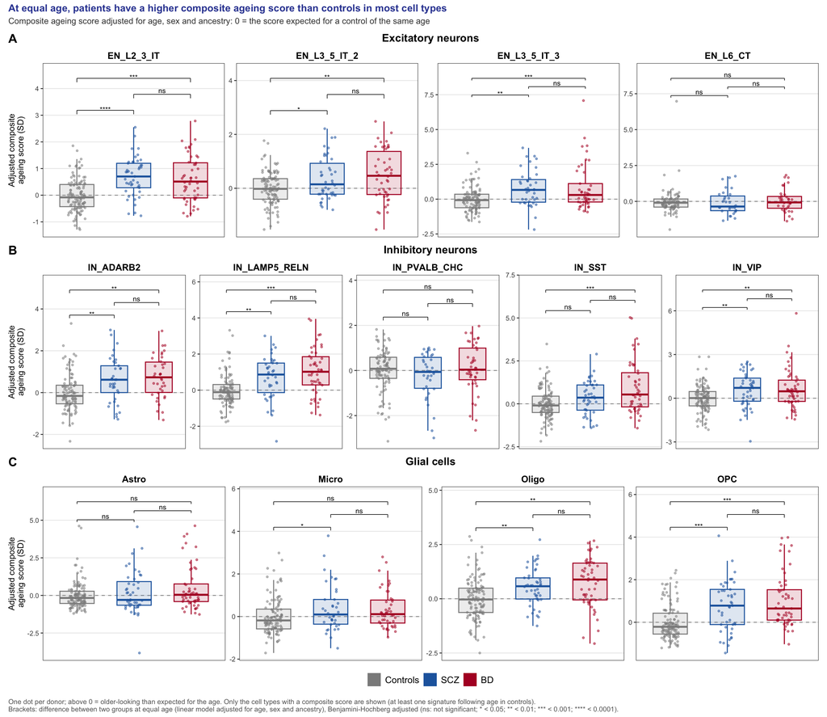

Figure 3

```r
p_F02 <- plot_composite_boxplots(model_data, models, cell_order = order_cell_types(model_data$cell_type),
                                 cols = c(Controls = "grey55", col_disease[c("SCZ", "BD")]),
                                 covariates = covariates, seed = the.seed)
p_F02
save_figure(p_F02, "Q5_F02_composite_score", fig_dir, width = 15, height = 13)
```

**Figure Q5-F02 – Composite ageing score of patients and controls at equal age.** For each donor, composite ageing score minus the score expected for a control of the same age, sex and ancestry (linear model fitted on controls), in the 13 cell types with a composite score, grouped by family. Brackets: difference between two groups at equal age (linear model adjusted for age, sex and ancestry), Benjamini–Hochberg adjusted.

**TipHow to read**

One box per group and cell type, one dot per donor. The dashed line (0) is what a control of the same age, sex and ancestry would have: a box above it means an older-looking profile. Each bracket compares two groups; “ns” means no significant difference.

**ImportantInterpretation**

- **Patients look older than controls of the same age in 10 of the 13 cell types, in SCZ and in BD alike.** The shift is significant in both diseases in upper-layer excitatory neurons (EN_L2_3_IT, EN_L3_5_IT_2, EN_L3_5_IT_3), in CGE-derived interneurons (IN_ADARB2, IN_LAMP5_RELN, IN_VIP), in OPC and in oligodendrocytes, from 0.35 to 0.97 control SD.
- **In one disease only**: microglia in SCZ (0.39 SD, adjusted p = 0.043) and IN_SST in BD (0.83 SD, adjusted p < 0.001). The direct SCZ vs BD test is not significant, so we do not call them specific.
- **No effect** in astrocytes, IN_PVALB_CHC and EN_L6_CT.
- **The effect is shared**: SCZ and BD do not differ in any cell type (direct test, adjusted p ≥ 0.71).

### How many years older?

```r
age_gap <- models |>
  filter(signature == "Composite_ageing_score", model == "offset", comparison != "SCZ_vs_BD") |>
  mutate(gap = ifelse(is.na(years_lower), "not estimable",
                      sprintf("%+.0f [%.0f; %.0f]", years, years_lower, years_upper))) |>
  select(cell_type, comparison, gap) |>
  pivot_wider(names_from = comparison, values_from = gap) |>
  mutate(cell_type = factor(cell_type, levels = order_cell_types(cell_type))) |>
  arrange(cell_type) |>
  rename(`Cell type` = cell_type, `SCZ (years, 95% CI)` = SCZ, `BD (years, 95% CI)` = BD)
write.csv(age_gap, file.path(out_dir, "apparent_age_gap.csv"), row.names = FALSE)
age_gap
```

| Cell type | SCZ (years, 95% CI) | BD (years, 95% CI) |
| --- | --- | --- |
| EN_L2_3_IT | +14 [9; 21] | +13 [7; 19] |
| EN_L3_5_IT_2 | +7 [2; 13] | +10 [5; 16] |
| EN_L3_5_IT_3 | +23 [8; 48] | +30 [14; 55] |
| EN_L6_CT | not estimable | not estimable |
| IN_ADARB2 | +22 [7; 48] | +24 [8; 48] |
| IN_LAMP5_RELN | +27 [9; 63] | +34 [16; 71] |
| IN_PVALB_CHC | -10 [-31; 11] | +9 [-10; 34] |
| IN_SST | +17 [-1; 51] | +37 [17; 81] |
| IN_VIP | +23 [6; 53] | +26 [9; 55] |
| Astro | +23 [-12; 414] | +29 [-8; 401] |
| Micro | +11 [1; 23] | +8 [-2; 18] |
| Oligo | +40 [12; 153] | +44 [16; 151] |
| OPC | +21 [10; 36] | +22 [12; 36] |

**TipHow to read**

One row per cell type: the apparent age gap of SCZ and BD patients compared with controls of the same age, in years, with its 95 % confidence interval (Fieller). “Not estimable”: the composite score does not clearly follow age in controls, so a shift cannot be converted into years.

**ImportantInterpretation**

- The most precise gaps are in **upper-layer excitatory neurons**: EN_L2_3_IT +14 years in SCZ [9; 21] and +13 in BD [7; 19]; EN_L3_5_IT_2 +7 [2; 13] and +10 [5; 16]. **Microglia**: +11 years in SCZ [1; 23].
- In interneurons and OPC, the gaps are larger (about +20 to +35 years) and less precise: the score changes slowly with age, so a moderate shift corresponds to many years.
- In oligodendrocytes and astrocytes, the intervals reach 150 to 400 years: the conversion has no meaning there, even when the shift itself is significant (oligodendrocytes). In EN_L6_CT, the gap is not estimable.
- The years are an order of magnitude, not a measure of how much faster patients age.

## Step A6 – Which hallmark drives the effect?

**What we do and why.** The composite ageing score is an average. To see which hallmark makes it rise, we test each of its scores separately, with the same offset model. Only the scores kept in the composite are shown, in the 13 cell types that have one; the other scores are not ageing measures in that cell type. These are secondary tests, corrected separately.

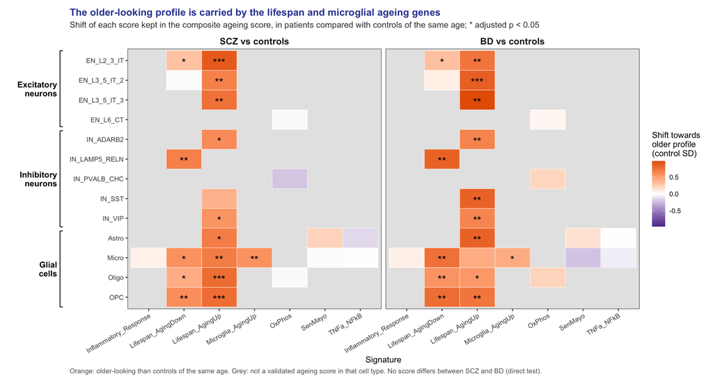

Figure 4

```r
p_F03 <- plot_score_shifts(models, alpha = alpha)
p_F03
save_figure(p_F03, "Q5_F03_score_shifts", fig_dir, width = 13, height = 7)
```

**Figure Q5-F03 – Shift of each score of the composite ageing score.** Difference between patients and controls of the same age (offset linear model adjusted for age, sex and genetic ancestry), in control SD, oriented so that positive values mean an older-looking profile, for each score kept in the composite ageing score, in the 13 cell types that have one, grouped by family. Benjamini–Hochberg adjusted: * < 0.05, ** < 0.01, *** < 0.001. Grey: not a validated ageing score in that cell type. No score differs between SCZ and BD (direct test, adjusted p ≥ 0.87).

**TipHow to read**

Same grid as F01. Each coloured cell is one score of the composite in one cell type: orange = patients look older on that score, white = no difference. Stars show which scores are significantly shifted, that is, which hallmark carries the effect seen in F02.

**ImportantInterpretation**

- **The shift is carried by the lifespan genes** in every cell type where the composite score shifts (0.31 to 0.97 SD), and in microglia also by the **microglial ageing genes** (0.56 SD in SCZ, 0.43 in BD).
- **Senescence, inflammation and TNFα/NF-κB do not move**, neither in microglia nor in astrocytes, although they follow age in controls: the older-looking profile is not a simple inflammatory effect of the disease or of the treatments.
- **Astrocytes**: the lifespan genes rising with age are shifted (0.68 SD in SCZ, 0.83 in BD), but the composite score is not, because it is diluted by the senescence and TNFα/NF-κB scores, which do not move.
- **OxPhos** is not shifted in any cell type where it is an ageing measure (EN_L6_CT, IN_PVALB_CHC, oligodendrocytes).
- **No score differs between SCZ and BD.**

## Step A7 – Do patients age faster?

**What we do and why.** Step A5 used the **offset model** and showed that patients look older than controls of the same age (Figure F02). This does not yet say whether they age *faster*, which is what “accelerated ageing” (H3) would mean. An older-looking profile can come from two situations. In the first, the patients’ line is parallel to the controls’ line, only higher: patients have a head start, the same at every age. In the second, the patients’ line is steeper: the gap grows with age, and patients age faster. The **slope model** (`score ~ age * diagnosis + sex + ancestry`) tests the second situation: does the composite score rise faster with age in patients than in controls? Detecting a difference of speed needs many donors across a wide age range, so the result is reported as a table.

```r
models |>
  filter(model == "slope", signature == "Composite_ageing_score") |>
  select(cell_type, comparison, aging_shift, lower, upper, p_adj) |>
  mutate(across(c(aging_shift, lower, upper), ~ round(.x, 3)))
```

| cell_type | comparison | aging_shift | lower | upper | p_adj |
| --- | --- | --- | --- | --- | --- |
| Astro | SCZ | -0.005 | -0.037 | 0.027 | 0.9186513 |
| Astro | BD | -0.021 | -0.048 | 0.005 | 0.4994706 |
| Astro | SCZ_vs_BD | 0.016 | -0.020 | 0.052 | 0.6289985 |
| EN_L2_3_IT | SCZ | 0.002 | -0.018 | 0.022 | 0.9186513 |
| EN_L2_3_IT | BD | -0.013 | -0.029 | 0.004 | 0.4994706 |
| EN_L2_3_IT | SCZ_vs_BD | 0.014 | -0.008 | 0.037 | 0.5050120 |
| EN_L3_5_IT_2 | SCZ | -0.009 | -0.031 | 0.012 | 0.9186513 |
| EN_L3_5_IT_2 | BD | -0.004 | -0.021 | 0.014 | 0.9186513 |
| EN_L3_5_IT_2 | SCZ_vs_BD | -0.006 | -0.030 | 0.019 | 0.8401078 |
| EN_L3_5_IT_3 | SCZ | 0.021 | -0.015 | 0.058 | 0.7728560 |
| EN_L3_5_IT_3 | BD | -0.005 | -0.034 | 0.024 | 0.9186513 |
| EN_L3_5_IT_3 | SCZ_vs_BD | 0.026 | -0.015 | 0.067 | 0.5050120 |
| EN_L6_CT | SCZ | -0.029 | -0.060 | 0.002 | 0.3972146 |
| EN_L6_CT | BD | -0.008 | -0.032 | 0.015 | 0.9186513 |
| EN_L6_CT | SCZ_vs_BD | -0.021 | -0.055 | 0.013 | 0.5050120 |
| IN_ADARB2 | SCZ | 0.000 | -0.030 | 0.030 | 0.9999231 |
| IN_ADARB2 | BD | 0.005 | -0.021 | 0.032 | 0.9186513 |
| IN_ADARB2 | SCZ_vs_BD | -0.005 | -0.041 | 0.030 | 0.8994027 |
| IN_LAMP5_RELN | SCZ | 0.010 | -0.021 | 0.041 | 0.9186513 |
| IN_LAMP5_RELN | BD | 0.009 | -0.016 | 0.035 | 0.9186513 |
| IN_LAMP5_RELN | SCZ_vs_BD | 0.001 | -0.035 | 0.036 | 0.9664239 |
| IN_PVALB_CHC | SCZ | 0.030 | 0.000 | 0.060 | 0.3972146 |
| IN_PVALB_CHC | BD | -0.023 | -0.047 | 0.002 | 0.3972146 |
| IN_PVALB_CHC | SCZ_vs_BD | 0.053 | 0.019 | 0.087 | 0.0336337 |
| IN_SST | SCZ | -0.006 | -0.037 | 0.026 | 0.9186513 |
| IN_SST | BD | -0.015 | -0.041 | 0.011 | 0.7728560 |
| IN_SST | SCZ_vs_BD | 0.009 | -0.027 | 0.045 | 0.8401078 |
| IN_VIP | SCZ | -0.003 | -0.034 | 0.028 | 0.9186513 |
| IN_VIP | BD | -0.002 | -0.027 | 0.023 | 0.9186513 |
| IN_VIP | SCZ_vs_BD | -0.001 | -0.036 | 0.034 | 0.9664239 |
| Micro | SCZ | 0.028 | 0.001 | 0.056 | 0.3972146 |
| Micro | BD | -0.002 | -0.023 | 0.020 | 0.9186513 |
| Micro | SCZ_vs_BD | 0.030 | -0.001 | 0.061 | 0.3876795 |
| OPC | SCZ | 0.013 | -0.016 | 0.041 | 0.9186513 |
| OPC | BD | -0.004 | -0.027 | 0.018 | 0.9186513 |
| OPC | SCZ_vs_BD | 0.017 | -0.015 | 0.049 | 0.5631221 |
| Oligo | SCZ | -0.004 | -0.031 | 0.023 | 0.9186513 |
| Oligo | BD | -0.023 | -0.045 | -0.001 | 0.3972146 |
| Oligo | SCZ_vs_BD | 0.019 | -0.012 | 0.049 | 0.5050120 |

**TipHow to read**

`aging_shift` is here the **extra change of the composite score per year of age** in patients compared with controls (for `SCZ_vs_BD`: in SCZ compared with BD). Detecting a difference of slope needs many donors across a wide age range, so this test is often not significant; it is reported as a table, and as a figure only if a result is found.

**ImportantInterpretation**

- **No**: in no cell type does the composite score rise faster with age in SCZ or BD (adjusted p ≥ 0.4). Patients look older by about the same amount at every age: a **head start rather than faster ageing**.
- The only significant result is a direct SCZ vs BD difference in IN_PVALB_CHC (adjusted p = 0.034), whose composite score rests on OxPhos alone and shows no shift: we do not interpret it. With only 34 donors aged 60 or more, a small difference of speed cannot be excluded.

## What Part A shows, and why Part B

Part A shows that, in 10 of the 13 cell types with a composite score, SCZ and BD patients look older than controls of the same age, by about the same amount at every age, and that this is carried by the lifespan genes rather than by inflammation or senescence. But Part A has two weaknesses: it depends on gene lists **chosen in advance**, and it covers only the 13 cell types where one of these lists follows age. Part B removes both: it uses **all genes**, in **all 23 cell types**.

# Part B – All genes

**The idea.** Instead of chosen gene lists, we compare two results computed on every gene. **The effect of age**: how each gene changes with age in controls (computed here). **The effect of the disease**: how each gene changes in patients compared with controls (Q2, DESeq2). If the disease looks like ageing, the genes that rise with age should also rise in patients, and the genes that fall with age should also fall. This is the approach of Fröhlich et al. [5], applied here to each cell type.

**The steps.** B1 measures this resemblance over all genes (a correlation). B2 checks, on the significant genes only, whether age and the disease change the same genes more often than by chance.

**What we expect.** If the disease profile resembles the ageing profile in a cell type, the correlation should be positive, and the genes shared by age and the disease should be more numerous than expected by chance and mostly changed in the same direction.

## Step B1 – Does the disease shift genes in the same direction as ageing?

**What we do and why.** The scores look at chosen gene lists. This test, close to the approach of [5], looks at **all genes**, without any list: in each cell type, it compares the effect of age on each gene (in controls) with the effect of the disease on the same gene (Q2, DESeq2 Wald statistic). If the genes that rise with age also rise in the disease, and the genes that fall with age also fall, the correlation is positive: the disease profile **resembles** the ageing profile. It helps to tell a broad ageing-like profile (high correlation) from a targeted effect, for example on inflammation only (low correlation).

**How.** The effect of age is a linear model per gene on the pseudobulk of the controls (`expression ~ age + sex + ancestry`), fitted for all genes at once. The Spearman correlation with the Q2 statistic is computed over all genes tested in both. To know which correlations can arise by chance, the ages of the controls are shuffled 1000 times (two-sided permutation test: a negative correlation, meaning a younger-looking profile, would also be detected). This needs the Q2 cell types to have the same names as the subclasses of the preprocessing.

```r
concordance <- NULL
if (file.exists(de_path)) {
  de <- read.csv(de_path)
  concordance <- bind_rows(lapply(names(age_fits), function(u) {
    if (is.null(age_fits[[u]])) return(NULL)
    bind_rows(lapply(c(SCZ = "SCZ_vs_CTRL", BD = "BD_vs_CTRL"), function(co) {
      d <- de[de$cell_type == u & de$contrast == co & !is.na(de$stat), ]
      if (nrow(d) == 0) return(NULL)
      res <- age_disease_concordance(age_fits[[u]], setNames(d$stat, d$gene), n_perm = n_perm, seed = the.seed)
      if (is.null(res)) return(NULL)
      cbind(cell_type = u, comparison = sub("_vs_CTRL", "", co), res)
    }))
  }))
  if (nrow(concordance) > 0) {
    concordance$p_adj <- p.adjust(concordance$p_perm, method = "BH")
    write.csv(concordance, file.path(out_dir, "age_disease_concordance.csv"), row.names = FALSE)
  } else {
    cat("Note: no cell type in common between Q2 and Q5: the concordance test is skipped.\n")
  }
} else {
  cat("Note: Q2 table not found, the concordance test is skipped.\n")
}
if (!is.null(concordance) && nrow(concordance) > 0) mutate(concordance, across(c(rho, null_low, null_high), ~ round(.x, 3)))
```

| cell_type | comparison | n_genes | rho | null_low | null_high | p_perm | p_adj |
| --- | --- | --- | --- | --- | --- | --- | --- |
| Astro | SCZ | 20165 | 0.280 | -0.256 | 0.251 | 0.0269730 | 0.0590838 |
| Astro | BD | 20165 | 0.155 | -0.187 | 0.191 | 0.1238761 | 0.1675971 |
| EN_L2_3_IT | SCZ | 20331 | 0.511 | -0.484 | 0.469 | 0.0359640 | 0.0689311 |
| EN_L2_3_IT | BD | 20331 | 0.348 | -0.221 | 0.219 | 0.0009990 | 0.0153180 |
| EN_L3_5_IT_1 | SCZ | 20304 | 0.251 | -0.352 | 0.330 | 0.1868132 | 0.2203438 |
| EN_L3_5_IT_1 | BD | 20304 | 0.088 | -0.133 | 0.131 | 0.2187812 | 0.2454619 |
| EN_L3_5_IT_2 | SCZ | 20157 | 0.357 | -0.351 | 0.343 | 0.0439560 | 0.0748881 |
| EN_L3_5_IT_2 | BD | 20157 | 0.179 | -0.150 | 0.139 | 0.0149850 | 0.0459540 |
| EN_L3_5_IT_3 | SCZ | 20077 | 0.448 | -0.407 | 0.393 | 0.0229770 | 0.0574426 |
| EN_L3_5_IT_3 | BD | 20077 | 0.247 | -0.171 | 0.189 | 0.0059940 | 0.0408480 |
| EN_L5_6_NP | SCZ | 20213 | 0.273 | -0.229 | 0.248 | 0.0159840 | 0.0459540 |
| EN_L5_6_NP | BD | 20213 | 0.166 | -0.103 | 0.104 | 0.0019980 | 0.0183816 |
| EN_L6B | SCZ | 20062 | 0.240 | -0.237 | 0.252 | 0.0539461 | 0.0855696 |
| EN_L6B | BD | 20062 | 0.183 | -0.215 | 0.214 | 0.1188811 | 0.1657131 |
| EN_L6_CT | SCZ | 19818 | 0.340 | -0.244 | 0.257 | 0.0069930 | 0.0408480 |
| EN_L6_CT | BD | 19818 | 0.261 | -0.231 | 0.224 | 0.0249750 | 0.0574426 |
| EN_L6_IT_1 | SCZ | 19957 | 0.319 | -0.254 | 0.265 | 0.0159840 | 0.0459540 |
| EN_L6_IT_1 | BD | 19957 | 0.297 | -0.199 | 0.208 | 0.0009990 | 0.0153180 |
| EN_L6_IT_2 | SCZ | 19882 | 0.253 | -0.197 | 0.211 | 0.0109890 | 0.0459540 |
| EN_L6_IT_2 | BD | 19882 | 0.194 | -0.182 | 0.186 | 0.0349650 | 0.0689311 |
| Endo | SCZ | 19313 | 0.035 | -0.244 | 0.253 | 0.7902098 | 0.8077700 |
| Endo | BD | 19313 | 0.118 | -0.150 | 0.152 | 0.1408591 | 0.1751222 |
| IN_ADARB2 | SCZ | 20141 | 0.335 | -0.328 | 0.329 | 0.0479520 | 0.0787784 |
| IN_ADARB2 | BD | 20141 | 0.139 | -0.119 | 0.120 | 0.0219780 | 0.0574426 |
| IN_LAMP5_LHX6 | SCZ | 19927 | 0.142 | -0.186 | 0.200 | 0.2177822 | 0.2454619 |
| IN_LAMP5_LHX6 | BD | 19927 | 0.070 | -0.093 | 0.108 | 0.1698302 | 0.2055839 |
| IN_LAMP5_RELN | SCZ | 19842 | 0.305 | -0.341 | 0.353 | 0.1048951 | 0.1507867 |
| IN_LAMP5_RELN | BD | 19842 | 0.098 | -0.125 | 0.125 | 0.1338661 | 0.1710512 |
| IN_PVALB | SCZ | 19922 | 0.425 | -0.372 | 0.354 | 0.0119880 | 0.0459540 |
| IN_PVALB | BD | 19922 | 0.203 | -0.161 | 0.151 | 0.0079920 | 0.0408480 |
| IN_PVALB_CHC | SCZ | 19523 | 0.140 | -0.217 | 0.211 | 0.2427572 | 0.2658770 |
| IN_PVALB_CHC | BD | 19523 | 0.024 | -0.106 | 0.116 | 0.7022977 | 0.7342203 |
| IN_SST | SCZ | 19642 | 0.427 | -0.376 | 0.360 | 0.0249750 | 0.0574426 |
| IN_SST | BD | 19642 | 0.264 | -0.166 | 0.161 | 0.0009990 | 0.0153180 |
| IN_VIP | SCZ | 20421 | 0.474 | -0.397 | 0.414 | 0.0149850 | 0.0459540 |
| IN_VIP | BD | 20421 | 0.254 | -0.179 | 0.187 | 0.0019980 | 0.0183816 |
| Micro | SCZ | 20072 | 0.236 | -0.217 | 0.222 | 0.0329670 | 0.0689311 |
| Micro | BD | 20072 | 0.241 | -0.191 | 0.190 | 0.0079920 | 0.0408480 |
| OPC | SCZ | 19935 | 0.228 | -0.229 | 0.256 | 0.0699301 | 0.1072261 |
| OPC | BD | 19935 | 0.166 | -0.179 | 0.192 | 0.0969031 | 0.1437917 |
| Oligo | SCZ | 19081 | 0.364 | -0.367 | 0.337 | 0.0439560 | 0.0748881 |
| Oligo | BD | 19081 | 0.285 | -0.276 | 0.272 | 0.0389610 | 0.0716883 |
| PC | SCZ | 19961 | 0.048 | -0.145 | 0.146 | 0.5334665 | 0.5706851 |
| PC | BD | 19961 | 0.116 | -0.141 | 0.144 | 0.1318681 | 0.1710512 |
| VLMC | SCZ | 20394 | -0.005 | -0.122 | 0.131 | 0.9440559 | 0.9440559 |
| VLMC | BD | 20394 | 0.091 | -0.070 | 0.067 | 0.0099900 | 0.0459540 |

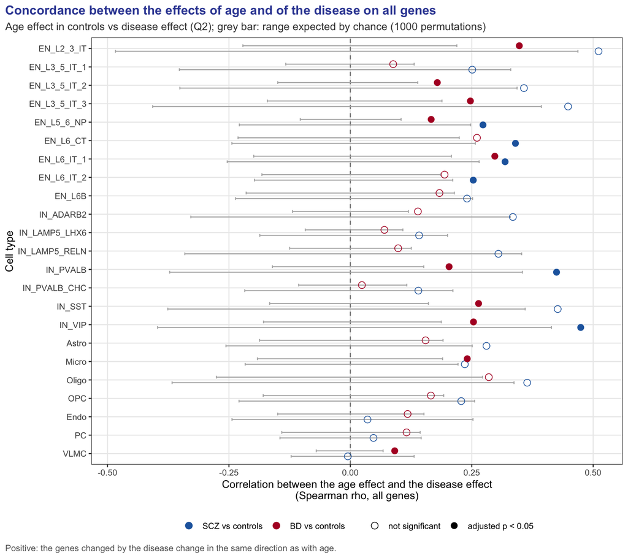

Figure 5

```r
if (!is.null(concordance) && nrow(concordance) > 0) {
  p_F04 <- concordance |>
    mutate(comparison = factor(comparison, levels = c("SCZ", "BD")),
           cell_type = factor(cell_type, levels = rev(order_cell_types(cell_type)))) |>   # grouped by family
    ggplot(aes(rho, cell_type, colour = comparison, group = comparison)) +
    geom_vline(xintercept = 0, linetype = "dashed", colour = "grey50") +
    geom_errorbar(aes(xmin = null_low, xmax = null_high), width = 0.3, orientation = "y", colour = "grey70",
                  position = position_dodge(width = 0.6)) +
    geom_point(aes(shape = p_adj < alpha), size = 3, position = position_dodge(width = 0.6)) +
    scale_colour_manual(values = c(SCZ = col_disease[["SCZ"]], BD = col_disease[["BD"]]),
                        labels = lab_dx, name = NULL) +
    scale_shape_manual(values = c(`FALSE` = 1, `TRUE` = 16),
                       labels = c(`FALSE` = "not significant", `TRUE` = paste0("adjusted p < ", alpha)), name = NULL) +
    labs(x = "Correlation between the age effect and the disease effect\n(Spearman rho, all genes)",
         y = "Cell type",
         title = "Concordance between the effects of age and of the disease on all genes",
         subtitle = paste0("Age effect in controls vs disease effect (Q2); grey bar: range expected by chance (", n_perm, " permutations)"),
         caption = "Positive: the genes changed by the disease change in the same direction as with age.") +
    theme_project()
  print(p_F04)
  save_figure(p_F04, "Q5_F04_age_disease_concordance", fig_dir, width = 9, height = 8)
}
```

**Figure Q5-F04 – Concordance between the effects of age and of the disease on gene expression.** For each cell type, Spearman correlation, over all genes tested in both analyses, between the effect of age in controls (t statistic of age in a pseudobulk linear model adjusted for sex and genetic ancestry) and the effect of the disease (DESeq2 Wald statistic, Q2), for SCZ (blue) and BD (red). Grey bars: 95 % range of the correlation expected by chance (ages permuted among controls). Filled dots: Benjamini–Hochberg adjusted permutation p < 0.05.

**TipHow to read**

A dot to the right of the grey bar means that the disease moves genes in the same direction as age, more than expected by chance: the disease profile resembles the ageing profile in that cell type. A dot inside the grey bar means no such resemblance.

**ImportantInterpretation**

- **The correlation is positive in 45 of the 46 comparisons** (all cell types, both diseases; the only exception is VLMC in SCZ, ρ = −0.01): the disease tends to move genes in the same direction as age.
- It is **stronger than chance** (adjusted p < 0.05) in **10 cell types in BD and 6 in SCZ**, mostly neurons: deep-layer excitatory neurons (EN_L5_6_NP and EN_L6_IT_1 in both diseases; EN_L6_CT and EN_L6_IT_2 in SCZ), IN_PVALB and IN_VIP (both), and, in BD, the upper-layer excitatory neurons, IN_SST and microglia. Several other cell types are close to the threshold (adjusted p 0.05 to 0.09).
- In SCZ, the correlations are higher (up to 0.51 in EN_L2_3_IT), but the range expected by chance is also wider (up to ±0.48), probably because SCZ changes large groups of genes together; a high correlation is therefore less often significant in SCZ than in BD.
- **Agreement with Part A is partial**: among the 10 cell types that look older in F02, the resemblance is significant in at least one disease in 6 (EN_L2_3_IT, EN_L3_5_IT_2, EN_L3_5_IT_3, IN_SST, IN_VIP, microglia), and not in IN_ADARB2, IN_LAMP5_RELN, OPC and oligodendrocytes (adjusted p 0.06 to 0.17). Part B also finds a resemblance in cell types without a composite score, such as the deep-layer excitatory neurons and IN_PVALB.

## Step B2 – Do age and the disease change the same genes?

**What we do and why.** B2 is a **complementary approach** to B1. B1 uses all genes and gives one number per cell type, a correlation, without saying which genes are involved. B2 looks only at the genes that change **significantly**, and asks a simpler question, as in [5]: are the genes changed with age and the genes changed in the disease **the same genes**, more often than by chance? The answer is a count that is easy to report, for example “695 genes in common, where 390 were expected by chance”.

**How.** In each cell type, every gene is placed in one of four boxes (“changed” = adjusted p < 0.05):

|  | changed in the disease (Q2) | not changed |
| --- | --- | --- |
| **changed with age** (controls) | a | b |
| **not changed with age** | c | d |

1. **Are there more shared genes than by chance?** Box *a* holds the genes changed both with age and in the disease. The **Fisher exact test** asks whether box *a* is fuller than expected by chance. The **odds ratio** says by how much: 1 = as expected by chance, 3 = three times more. The test is one-sided because it is an enrichment test: fewer shared genes than by chance would have no biological meaning here (the ORA of Q3 uses the same convention).
2. **Do they change in the same direction?** Among the genes of box *a*, we count those that change in the same direction with age and with the disease (up and up, or down and down). A two-sided **binomial test** checks whether this share differs from 50 %, which is what chance would give. A majority in the same direction means an ageing-like profile; a majority in opposite directions would mean a younger-looking one.

**Limit.** The Fisher test treats genes as independent, while genes of the same pathway change together: its p-values are therefore too optimistic, and the result depends on the significance threshold. B1 remains the main test, and B2 backs it up with readable counts.

```r
overlap <- NULL
if (file.exists(de_path)) {
  overlap <- bind_rows(lapply(names(age_fits), function(u) {
    if (is.null(age_fits[[u]])) return(NULL)
    bind_rows(lapply(c(SCZ = "SCZ_vs_CTRL", BD = "BD_vs_CTRL"), function(co) {
      d <- de[de$cell_type == u & de$contrast == co, ]
      if (nrow(d) == 0) return(NULL)
      res <- age_disease_overlap(age_fits[[u]], setNames(d$stat, d$gene), setNames(d$padj, d$gene), alpha = alpha)
      if (is.null(res)) return(NULL)
      cbind(cell_type = u, comparison = sub("_vs_CTRL", "", co), res)
    }))
  }))
  if (nrow(overlap) > 0) {
    overlap$p_adj_fisher    <- p.adjust(overlap$p_fisher, method = "BH")
    overlap$p_adj_direction <- p.adjust(overlap$p_direction, method = "BH")
    write.csv(overlap, file.path(out_dir, "age_disease_overlap_fisher.csv"), row.names = FALSE)
    overlap |>
      transmute(cell_type, comparison, n_age, n_disease, n_both, expected_both,
                odds_ratio = round(odds_ratio, 2), p_adj_fisher = signif(p_adj_fisher, 2),
                pct_same_direction, p_adj_direction = signif(p_adj_direction, 2))
  }
}
```

| cell_type | comparison | n_age | n_disease | n_both | expected_both | odds_ratio | p_adj_fisher | pct_same_direction | p_adj_direction |
| --- | --- | --- | --- | --- | --- | --- | --- | --- | --- |
| Astro | SCZ | 372 | 451 | 65 | 8.3 | 10.63 | 0.0e+00 | 100.0 | 0.0e+00 |
| Astro | BD | 372 | 1046 | 63 | 19.3 | 3.90 | 0.0e+00 | 88.9 | 0.0e+00 |
| EN_L2_3_IT | SCZ | 3609 | 2197 | 695 | 390.3 | 2.41 | 0.0e+00 | 96.8 | 0.0e+00 |
| EN_L2_3_IT | BD | 3609 | 566 | 227 | 100.5 | 3.24 | 0.0e+00 | 97.8 | 0.0e+00 |
| EN_L3_5_IT_1 | SCZ | 497 | 538 | 41 | 15.6 | 2.93 | 0.0e+00 | 95.1 | 0.0e+00 |
| EN_L3_5_IT_1 | BD | 443 | 41 | 2 | 0.9 | 2.30 | 2.7e-01 | 100.0 | NA |
| EN_L3_5_IT_2 | SCZ | 2233 | 688 | 174 | 76.9 | 2.83 | 0.0e+00 | 89.7 | 0.0e+00 |
| EN_L3_5_IT_2 | BD | 2239 | 258 | 75 | 28.7 | 3.36 | 0.0e+00 | 92.0 | 0.0e+00 |
| EN_L3_5_IT_3 | SCZ | 1938 | 919 | 235 | 88.7 | 3.52 | 0.0e+00 | 97.4 | 0.0e+00 |
| EN_L3_5_IT_3 | BD | 1938 | 287 | 82 | 27.7 | 3.86 | 0.0e+00 | 93.9 | 0.0e+00 |
| EN_L5_6_NP | SCZ | 201 | 78 | 12 | 4.5 | 3.12 | 2.2e-03 | 91.7 | 7.5e-03 |
| EN_L5_6_NP | BD | 235 | 31 | 5 | 0.4 | 16.67 | 5.9e-05 | 100.0 | 6.3e-02 |
| EN_L6B | SCZ | 447 | 98 | 10 | 4.4 | 2.46 | 1.7e-02 | 100.0 | 2.4e-03 |
| EN_L6B | BD | 384 | 78 | 4 | 1.5 | 2.79 | 8.0e-02 | 100.0 | NA |
| EN_L6_CT | SCZ | 565 | 158 | 38 | 6.8 | 7.51 | 0.0e+00 | 97.4 | 0.0e+00 |
| EN_L6_CT | BD | 506 | 55 | 10 | 1.4 | 8.63 | 2.7e-06 | 100.0 | 2.4e-03 |
| EN_L6_IT_1 | SCZ | 580 | 148 | 36 | 6.4 | 7.52 | 0.0e+00 | 100.0 | 0.0e+00 |
| EN_L6_IT_1 | BD | 526 | 96 | 10 | 2.5 | 4.36 | 4.2e-04 | 100.0 | 2.4e-03 |
| EN_L6_IT_2 | SCZ | 71 | 76 | 5 | 0.7 | 8.64 | 8.7e-04 | 100.0 | 6.3e-02 |
| EN_L6_IT_2 | BD | 38 | 96 | 2 | 0.3 | 8.38 | 3.7e-02 | 100.0 | NA |
| Endo | SCZ | 22 | 1116 | 6 | 1.7 | 4.60 | 7.4e-03 | 100.0 | 3.3e-02 |
| Endo | BD | 55 | 118 | 1 | 0.8 | 1.25 | 6.4e-01 | 100.0 | NA |
| IN_ADARB2 | SCZ | 253 | 326 | 21 | 7.7 | 3.00 | 6.7e-05 | 100.0 | 1.9e-06 |
| IN_ADARB2 | BD | 272 | 24 | 0 | 0.3 | 0.00 | 1.0e+00 | NA | NA |
| IN_LAMP5_LHX6 | SCZ | 8 | 1 | 0 | 0.0 | 0.00 | 1.0e+00 | NA | NA |
| IN_LAMP5_LHX6 | BD | 10 | 81 | 0 | 0.1 | 0.00 | 1.0e+00 | NA | NA |
| IN_LAMP5_RELN | SCZ | 44 | 332 | 3 | 1.0 | 3.09 | 1.0e-01 | 100.0 | NA |
| IN_LAMP5_RELN | BD | 45 | 104 | 0 | 0.2 | 0.00 | 1.0e+00 | NA | NA |
| IN_PVALB | SCZ | 448 | 256 | 24 | 7.4 | 3.60 | 1.2e-06 | 95.8 | 5.3e-06 |
| IN_PVALB | BD | 422 | 233 | 12 | 4.9 | 2.55 | 6.7e-03 | 100.0 | 6.8e-04 |
| IN_PVALB_CHC | SCZ | 253 | 183 | 12 | 3.4 | 3.83 | 3.3e-04 | 100.0 | 6.8e-04 |
| IN_PVALB_CHC | BD | 236 | 60 | 3 | 0.9 | 3.55 | 7.7e-02 | 100.0 | NA |
| IN_SST | SCZ | 1982 | 836 | 210 | 103.2 | 2.55 | 0.0e+00 | 99.0 | 0.0e+00 |
| IN_SST | BD | 2116 | 108 | 31 | 11.6 | 3.37 | 6.0e-07 | 90.3 | 7.8e-06 |
| IN_VIP | SCZ | 1383 | 722 | 119 | 48.9 | 2.88 | 0.0e+00 | 100.0 | 0.0e+00 |
| IN_VIP | BD | 1383 | 140 | 18 | 9.5 | 2.04 | 9.6e-03 | 100.0 | 1.2e-05 |
| Micro | SCZ | 668 | 293 | 48 | 13.5 | 4.30 | 0.0e+00 | 100.0 | 0.0e+00 |
| Micro | BD | 654 | 493 | 68 | 24.1 | 3.35 | 0.0e+00 | 98.5 | 0.0e+00 |
| OPC | SCZ | 453 | 118 | 20 | 3.8 | 6.32 | 0.0e+00 | 100.0 | 3.6e-06 |
| OPC | BD | 445 | 515 | 30 | 12.4 | 2.62 | 1.9e-05 | 90.0 | 1.3e-05 |
| Oligo | SCZ | 143 | 139 | 6 | 1.0 | 6.19 | 1.1e-03 | 100.0 | 3.3e-02 |
| Oligo | BD | 142 | 144 | 6 | 1.1 | 5.90 | 1.4e-03 | 100.0 | 3.3e-02 |
| PC | SCZ | 16 | 385 | 2 | 0.6 | 3.56 | 1.5e-01 | 100.0 | NA |
| PC | BD | 17 | 511 | 4 | 1.3 | 3.87 | 4.4e-02 | 100.0 | NA |
| VLMC | SCZ | 25 | 56 | 0 | 0.1 | 0.00 | 1.0e+00 | NA | NA |
| VLMC | BD | 18 | 0 | 0 | 0.0 | 0.00 | 1.0e+00 | NA | NA |

**Table – Overlap between age-associated and disease-associated genes.** `n_age`, `n_disease`: genes significant with age in controls and in the disease (Q2); `n_both`: genes significant in both; `expected_both`: number expected by chance; `odds_ratio` and `p_adj_fisher`: one-sided Fisher exact test; `pct_same_direction` and `p_adj_direction`: percentage of common genes changed in the same direction, binomial test against 50 %. Benjamini–Hochberg correction over cell types and diseases. If very few genes are significant with age (few controls), the test has little power: a non-significant result then means “not testable”, not “no overlap”.

# Conclusion

**ImportantSummary table**

| Element | Result | Figure |
| --- | --- | --- |
| Scores that follow age in controls | 13 of 23 cell types; lifespan signatures in most of them, all hallmarks in microglia, senescence and TNFα/NF-κB in astrocytes; myelination never | F01 |
| Older-looking than controls of the same age, SCZ | EN_L2_3_IT (+14 years), EN_L3_5_IT_2 (+7), EN_L3_5_IT_3, IN_ADARB2, IN_LAMP5_RELN, IN_VIP, OPC (+21), oligodendrocytes, microglia (+11) | F02, table |
| Older-looking, BD | the same cell types except microglia, plus IN_SST; EN_L2_3_IT +13, EN_L3_5_IT_2 +10, OPC +22 | F02, table |
| Shared or specific? | shared: the direct SCZ vs BD test is not significant in any of the 13 cell types (adjusted p ≥ 0.71) | F02 |
| Hallmarks driving the effect | lifespan genes, and microglial ageing genes in microglia; not inflammation, senescence or OxPhos | F03 |
| Faster change with age? | no, in any cell type: a head start, not faster ageing | table (A7) |
| Disease moves genes like age (all genes) | positive in 45 of 46 comparisons; above chance in 10 cell types in BD and 6 in SCZ, mostly neurons | F04 |
| Same significant genes, same direction | more shared genes than by chance in 34 of 46 comparisons (odds ratio 2–17), 89–100 % in the same direction | table (B2) |
| **Is H3 supported?** | **Partly**: an older-looking profile, shared by SCZ and BD, but not faster ageing |  |

**Answer to Q5.** In the HBCC cohort, schizophrenia and bipolar disorder share an **older-looking transcriptomic profile** in several cell types. The evidence is strongest where both parts of the notebook agree: in upper-layer excitatory neurons (EN_L2_3_IT, EN_L3_5_IT_2, EN_L3_5_IT_3), in IN_VIP and IN_SST interneurons and in microglia, patients look older than controls of the same age (Part A), and the disease moves all genes in the same direction as age (Part B). In IN_ADARB2, IN_LAMP5_RELN, OPC and oligodendrocytes, the composite score is shifted but the all-gene correlation does not reach significance. The profile is carried by the genes that change with age in the healthy brain, not by inflammation or senescence, and it is the same at every age: patients do not age faster. It is a resemblance between donors, not a proof of ageing; treatments, ancestry and the cause of death cannot be excluded.

**In one sentence:** SCZ and BD share an older-looking expression profile in several neuronal and glial cell types, which looks like a head start on normal ageing rather than faster ageing or an inflammatory process.

**Is H3 supported?** Partly. Patients do have an ageing-like profile, shared by the two disorders, as H3 predicts. But “accelerated” ageing in the strict sense, a gap that grows with age, is not found, although our power to detect it is limited (few donors over 60).

**Our results in the light of the literature.** The closest study, in the orbitofrontal cortex, found that the transcriptomic effects of psychiatric disorders and of ageing converge, with most shared genes changed in the same direction [5]; we find the same convergence in the dorsolateral prefrontal cortex, cell type by cell type, with an even higher agreement of direction. At the scale of the whole brain, MRI studies find that the brain of patients looks older than their age in SCZ and, to a lesser extent, in BD [3], whereas epigenetic clocks find no accelerated ageing in the SCZ brain [4]: our results, an older-looking profile that does not grow with age, fit between these two views. In the same cortex, a program shared by neurons and astrocytes declines both with age and in SCZ [6]; we also find older-looking profiles in upper-layer neurons, and in astrocytes the lifespan genes are shifted, although the composite score is not.

**Links with the other questions.**

- **Q1**: only two subclasses change in proportion in Q1, microglia (fewer cells in SCZ and BD) and oligodendrocytes (fewer in BD). Both also look older here (microglia in SCZ, oligodendrocytes in both diseases); but most of the older-looking cell types (upper-layer neurons, interneurons, OPC) do not change in number. An ageing-like profile does not require a loss of cells, which justifies analysing all subclasses.
- **Q3**: GSEA finds inflammatory pathways shifted in glial cells in both disorders, whereas the inflammatory ageing scores are not shifted here. GSEA can detect small coordinated shifts that an average score misses; in any case, inflammation is not what makes patients look older.
- **Q4**: ageing also alters communication between cells [1]. Q4 finds changes in the signalling between neurons and the oligodendrocyte lineage, and weaker GABAergic signalling, which involve cell types that look older here (OPC, oligodendrocytes, interneurons). Q4 is exploratory, so this link remains a hypothesis.

# Limits

- **Cross-sectional design.** Each donor is seen once: an ageing-like profile is inferred between donors, not followed over time.
- **Not a proof of ageing.** A profile that resembles ageing can have other causes; we only describe a resemblance.
- **Treatments and metabolic disorders.** Antipsychotics, lithium and smoking change inflammation, metabolic and myelin genes. Donors with metabolic disorders (for example diabetes) are kept, as in Lee et al. [8]; these disorders are more frequent in patients (partly because of antipsychotics), and are themselves associated with accelerated ageing. We did not repeat the analysis without these donors. In HBCC, diabetes is more frequent in SCZ (27 %) than in controls (7 %) and BD (9 %), and tardive dyskinesia (a side effect of long antipsychotic treatment) concerns 24 % of SCZ donors (preprocessing, Table 1).
- **Genetic ancestry.** Ancestry is strongly linked to the diagnosis (most BD donors are of European ancestry, most SCZ donors of African ancestry). It is a covariate of every model, but a residual confounding cannot be excluded, mainly for the direct SCZ vs BD comparison.
- **No post-mortem interval.** The PMI is not available in the data and is not in the models.
- **Few old donors.** Only 34 donors are 60 or older (15 controls, 13 SCZ, 6 BD): the effect of age is estimated mostly before 60, and the slope model has little power.
- **Survival bias and cause of death.** Patients die younger on average; the cause of death (for example suicide) can affect the brain transcriptome.
- **The composite ageing score covers only part of ageing.** Several hallmark signatures did not follow age in our controls and were left out, possibly because they were built in other tissues or cell types, because senescence and chronic inflammation mostly appear after 60–70 years (most of our controls are younger), or because of the limited power of snRNA-seq data. The composite score therefore rests mostly on the lifespan signatures. When we find no shift in senescence or inflammation, this means “not detected with these lists in these donors”, not “absent”.
- **Lifespan signatures and our controls.** The lifespan atlas was built partly on HBCC controls [13], so these signatures are not independent of our controls. Most composite ageing scores rest on these signatures: their validation in our controls is partly circular, but the disease effect, measured in patients, is not.
- **Power.** With few donors per group in some cell types, the absence of an effect is not evidence of no effect; the direct SCZ vs BD test has even less power.
- **Choice of signatures.** We kept a few well-established hallmarks; others (oxidative stress, NAD+ and sirtuins, proteostasis and autophagy, nutrient sensing) were not tested.

# List of figures

Figures are saved as `.png` in `04_FIGURES/Q5_aging/`. Checks and intermediate results (donors, analysis units, coverage and overlap of the signatures, components of the composite score, apparent age gap, slope model, overlap of significant genes) are tables.

| Figure | File | What it shows | Why we need it |
| --- | --- | --- | --- |
| — | `Q5_reasoning` | how the notebook answers Q5 | gives the logic before any result |
| F01 | `Q5_F01_validation_controls` | correlation of each score with age in controls | proves that our scores measure ageing |
| F02 | `Q5_F02_composite_score` | composite ageing score of patients and controls at equal age | main result of Part A |
| F03 | `Q5_F03_score_shifts` | shift of each score of the composite | which hallmark drives the effect |
| F04 | `Q5_F04_age_disease_concordance` | concordance of the age and disease effects on all genes | confirmation without gene lists |

```r
sort(list.files(fig_dir, pattern = "^Q5_F.*\\.png$"))
```

```
[1] "Q5_F01_validation_controls.png"     "Q5_F02_composite_score.png"
[3] "Q5_F03_score_shifts.png"            "Q5_F04_age_disease_concordance.png"
```

# References

1. López-Otín C., Blasco M. A., Partridge L., Serrano M., Kroemer G. (2023). Hallmarks of aging: an expanding universe. *Cell*, 186, 243–278.
2. Mattson M. P., Arumugam T. V. (2018). Hallmarks of brain aging: adaptive and pathological modification by metabolic states. *Cell Metabolism*, 27, 1176–1199.
3. Kaufmann T. et al. (2019). Common brain disorders are associated with heritable patterns of apparent aging of the brain. *Nature Neuroscience*, 22, 1617–1623.
4. McKinney B. C. et al. (2017). DNA methylation evidence against the accelerated aging hypothesis of schizophrenia. *npj Schizophrenia*, 3, 13.
5. Fröhlich A. S. et al. (2024). Single-nucleus transcriptomic profiling of human orbitofrontal cortex reveals convergent effects of aging and psychiatric disease. *Nature Neuroscience*, 27, 2021–2032.
6. Ling E. et al. (2024). A concerted neuron–astrocyte program declines in ageing and schizophrenia. *Nature*, 627, 604–611.
7. Hao Y. et al. (2024). Dictionary learning for integrative, multimodal and scalable single-cell analysis (Seurat v5). *Nature Biotechnology*, 42, 293–304.
8. Lee D. et al. (2026). Single-cell atlas of transcriptomic vulnerability across brain disorders. *Nature*, 657, 988–1002.
9. Saul D. et al. (2022). A new gene set identifies senescent cells and predicts senescence-associated pathways across tissues. *Nature Communications*, 13, 4827.
10. Liberzon A. et al. (2015). The Molecular Signatures Database hallmark gene set collection. *Cell Systems*, 1, 417–425.
11. Galatro T. F. et al. (2017). Transcriptomic analysis of purified human cortical microglia reveals age-associated changes. *Nature Neuroscience*, 20, 1162–1171.
12. The Gene Ontology Consortium (2023). The Gene Ontology knowledgebase in 2023. *Genetics*, 224, iyad031.
13. Yang H., Clarence T., Scott M. R. et al. (2026). Lifespan single-cell transcriptomic atlas of the human prefrontal cortex. *Nature*, 657, 1003–1015. doi:10.1038/s41586-026-10271-7 (preprint: medRxiv 10.1101/2024.11.06.24316592)
14. Ciernik L., Kraft A., Barkmann F., Yates J., Boeva V. (2026). Robust and efficient annotation of cell states through gene signature scoring. *Genome Research*, 36, 630–644. doi:10.1101/gr.280926.125
15. Fieller E. C. (1954). Some problems in interval estimation. *Journal of the Royal Statistical Society B*, 16, 175–185.